# Detailed Data Analysis: chefkoch.de

### Table of contents:

1. Exploratory Analysis
   - General Statistics & Data Quality
   - Users
   - Recipes
   - Text Mining
     - Title Analysis
     - Ingredient Analysis
     - Feature Extraction
   - Dataset with Generated Features
2. Trend Analysis
3. Data Mining

# 1. Exploratory Analysis

## General Statistics & Data Quality

First, we do all necessary imports and convert the data from its list format to a pandas DataFrame for further operations. Then, we show meta information about density/sparsity of each column.

### Import packages and data

```python
import json
import pandas as pd
import matplotlib.pyplot as plt
%matplotlib inline
```

```python
# Read json file into a list
with open('data/chefkoch_03.json') as data_file:
    chefkoch = json.load(data_file)
```

### Data structure

To understand the data structure that the scraper has exported, we can take a look at the first element from the list chefkoch. This is a dictionary that contains a single recipe.

```python
chefkoch[0]
```

```
{'avg_rating': 'Ø4,87',
 'calories': 'keineAngabe',
 'date': '26.06.2013',
 'difficulty': 'normal',
 'ingredients': ['5EL',
  'Zucker,braun',
  '3EL',
  'Paprikapulver,edelsüß',
  '1EL',
  '1EL',
  'Pfeffer',
  '1EL',
  'Paprikapulver,scharf',
  '1EL',
  'Chilipulver',
  '1EL',
  'Zwiebelpulver',
  '1EL',
  'Knoblauchpulver',
  '300ml',
  'Orangensaft',
  '100ml',
  '150ml',
  'Ketchup',
  '1EL',
  'Worcestersauce',
  '2EL',
  'Marinade(vondemRub)',
  '2EL',
  'Honig',
  '50ml',
  'BBQ-Sauce',
  '2EL',
  'Zucker,braun',
  '6kg'],
 'name': 'Köstliche BBQ Spareribs für Smoker und Backofen mit Soße und Gewürzmischung',
 'number_ratings': '236',
 'preparation': ' Hinweis: 1 EL Salz und 1 EL Pfeffer kann man ersetzen durch 2 EL Steak-Gewürzsalz von Wiberg.Zubereitung Rub:Alle Zutaten in einen Mörser und ein wenig zerstampfen und vermengen. Der Rub kann danach in einem entsprechenden Gewürzdöschen problemlos mehrere Wochen aufbewahrt werden. …
 'printed': '57.547(44)*',
 'saved': '6.507(3)*',
 'shared': '49(0)*',
 'subtitle': 'Ich mache meine Spareribs nun schon sehr lange auf diese Weise, egal ob Smoker oder Backofen jeder fährt darauf ab!!',
 'time_cook': 'ca.4Std.30Min.',
 'time_rest': 'ca.12Std.',
 'time_work': 'ca.1Std.',
 'user': 'cualalumpur',
 'user_activity': '0 Beiträge (ø0/Tag)',
 'user_date': 'Mitglied seit 09.10.2012'}
```

Thus, we can see that our dataset is a list of dictionaries, of which each is a single recipe. The dictionary itself consists of text fields that are all either filled with a string or None, if they are empty.

```python
# The json is imported as a list of dictionaries filled with strings
type(chefkoch), type(chefkoch[0]), type(chefkoch[0]['avg_rating'])
```

```
(list, dict, str)
```

```python
#  Finding missing values (empty strings) and replacing them with None:
for i, r in enumerate(chefkoch):
    # Replace empty strings by None
    for column in chefkoch[i]:
        if chefkoch[i][column] == '':
            chefkoch[i][column] = None
```

```python
# Are other attributes affected as well?
# chefkoch[errors[0]]
```

After converting the dataset into a DataFrame, we can easily see how many values are missing:

```python
chefdf = pd.DataFrame(chefkoch)
chefdf.info()
```

```
<class 'pandas.core.frame.DataFrame'>
RangeIndex: 319578 entries, 0 to 319577
Data columns (total 18 columns):
avg_rating        223542 non-null object
calories          319578 non-null object
date              319578 non-null object
difficulty        319578 non-null object
ingredients       319578 non-null object
name              319578 non-null object
number_ratings    319578 non-null object
preparation       319578 non-null object
printed           319578 non-null object
saved             319578 non-null object
shared            319578 non-null object
subtitle          164336 non-null object
time_cook         114652 non-null object
time_rest         72939 non-null object
time_work         319578 non-null object
user              319578 non-null object
user_activity     319578 non-null object
user_date         319578 non-null object
dtypes: object(18)
memory usage: 43.9+ MB
```

```python
print(chefdf['number_ratings'].describe())
print(chefdf['printed'].describe())
print(chefdf['saved'].describe())
print(chefdf['shared'].describe())
```

```
count             319578
unique               730
top       Freischaltung:
freq               96036
Name: number_ratings, dtype: object
count          319578
unique          36477
top       verschickt:
freq            96036
Name: printed, dtype: object
count        319578
unique         9041
top       gedruckt:
freq          96036
Name: saved, dtype: object
count     319578
unique      2539
top        0(0)*
freq       61373
Name: shared, dtype: object
```

Due to a previously unknown error during scraping (as it has not produced an error message in its log), some values of 96,036 recipes could not be recorded correctly. Unfortunately, this error has been recognised too late, which is why those entries will be missing in all six datasets.

These 96,036 recipes without date also lack values in the other fields. Due to this reason, those recipes need to be removed from the dataset completely. Unfortunately, we are forced to reduce the dataset by almost a third because of this. However, we can gather some statistics before dropping the affected entries:

```python
# Splitting the date and creating new columns for year, month and day
# and cleaning some other values:

def clean_dataset(data):
    date = []
    errors = []
    for i, r in enumerate(data):
        date = data[i]['date'].split('.')
        data[i]['printed'] = data[i]['printed'].split('(')[0].replace('.','')
        data[i]['saved'] = data[i]['saved'].split('(')[0].replace('.','')
        data[i]['shared'] = data[i]['shared'].split('(')[0].replace('.','')

        # For all complete recipes, produce date features
        try:
            data[i]['year'] = date[2]
            data[i]['month'] = date[1]
            data[i]['day'] = date[0]

        # For all others, set dirty values to None
        except IndexError:
            errors.append(i)
            data[i]['date'] = None
            data[i]['printed'] = None
            data[i]['saved'] = None
            data[i]['shared'] = None
            data[i]['number_ratings'] = 0

    print(len(errors))

clean_dataset(chefkoch)
```

```
96036
```

```python
chefdf = pd.DataFrame(chefkoch)
```

```python
chefdf.info()
```

```
<class 'pandas.core.frame.DataFrame'>
RangeIndex: 319578 entries, 0 to 319577
Data columns (total 21 columns):
avg_rating        223542 non-null object
calories          319578 non-null object
date              223542 non-null object
day               223542 non-null object
difficulty        319578 non-null object
ingredients       319578 non-null object
month             223542 non-null object
name              319578 non-null object
number_ratings    319578 non-null object
preparation       319578 non-null object
printed           223542 non-null object
saved             223542 non-null object
shared            223542 non-null object
subtitle          164336 non-null object
time_cook         114652 non-null object
time_rest         72939 non-null object
time_work         319578 non-null object
user              319578 non-null object
user_activity     319578 non-null object
user_date         319578 non-null object
year              223542 non-null object
dtypes: object(21)
memory usage: 51.2+ MB
```

#### General Statistics

- How many unique authors can be found in the dataset? (users with at least 1 recipe)

```python
# Total number of unique active users (at least 1 recipe published)
len(chefdf['user'].value_counts())
```

```
80459
```

- How many recipes have been published on this platform?

```python
len(chefdf['date'])
```

```
319578
```

- When were the first recipes published?

```python
chefdf['date'] = pd.to_datetime(chefdf['date'], format="%d.%m.%Y")
print(chefdf['date'].nsmallest(10))
```

```
21750    2000-10-18
81247    2000-10-30
45946    2000-10-31
59198    2000-10-31
80934    2000-10-31
83863    2000-10-31
164591   2000-10-31
205924   2000-11-06
63564    2000-11-07
49381    2000-11-13
Name: date, dtype: datetime64[ns]
```

- How many times have the users voted for a rating?

```python
chefdf['number_ratings'] = pd.to_numeric(chefdf['number_ratings'])
print(chefdf['number_ratings'].sum())
```

```
2559356
```

#### Calculating deltas

For comparing the main statistics with older dataset versions, we will use the 1 month (chef1 / chef1df) and 6 months (chef6 / chef6df) older versions.

First, chef1:

```python
with open('data/chefkoch_02.json') as data_file:
    chef1 = json.load(data_file)
clean_dataset(chef1)
chef1df = pd.DataFrame(chef1)
chef1df.info()
```

```
95821
<class 'pandas.core.frame.DataFrame'>
RangeIndex: 318240 entries, 0 to 318239
Data columns (total 21 columns):
avg_rating        222419 non-null object
calories          318240 non-null object
date              222419 non-null object
day               222419 non-null object
difficulty        318240 non-null object
ingredients       318240 non-null object
month             222419 non-null object
name              318240 non-null object
number_ratings    318240 non-null object
preparation       318240 non-null object
printed           222419 non-null object
saved             222419 non-null object
shared            222419 non-null object
subtitle          163448 non-null object
time_cook         318240 non-null object
time_rest         318240 non-null object
time_work         318240 non-null object
user              318240 non-null object
user_activity     318240 non-null object
user_date         318240 non-null object
year              222419 non-null object
dtypes: object(21)
memory usage: 51.0+ MB
```

```python
# Number of recipes
print(len(chef1df['name']))
print(len(chefdf['name'])-len(chef1df['name']))
```

```
318240
1338
```

```python
# Number of distinct authors
print(len(chef1df['user'].value_counts()))
print(len(chefdf['user'].value_counts())-len(chef1df['user'].value_counts()))
```

```
80069
390
```

```python
# Number of total votes
chef1df['number_ratings'] = pd.to_numeric(chef1df['number_ratings'])
print(chef1df['number_ratings'].sum())
print(chefdf['number_ratings'].sum()-chef1df['number_ratings'].sum())
```

```
2538237
21119
```

Now we cann do the same for koch6:

```python
with open('data/chefkoch_10.json') as data_file:
    chef6 = json.load(data_file)
clean_dataset(chef6)
chef6df = pd.DataFrame(chef6)
chef6df.info()
```

```
96493
<class 'pandas.core.frame.DataFrame'>
RangeIndex: 313751 entries, 0 to 313750
Data columns (total 21 columns):
avg_rating        217258 non-null object
calories          313751 non-null object
date              217258 non-null object
day               217258 non-null object
difficulty        313751 non-null object
ingredients       313751 non-null object
month             217258 non-null object
name              313751 non-null object
number_ratings    313751 non-null object
preparation       313751 non-null object
printed           217258 non-null object
saved             217258 non-null object
shared            217258 non-null object
subtitle          160564 non-null object
time_cook         313751 non-null object
time_rest         313751 non-null object
time_work         313751 non-null object
user              313751 non-null object
user_activity     313751 non-null object
user_date         313751 non-null object
year              217258 non-null object
dtypes: object(21)
memory usage: 50.3+ MB
```

```python
# Number of recipes
print(len(chef6df['name']))
print(len(chefdf['name'])-len(chef6df['name']))
```

```
313751
5827
```

```python
# Number of distinct authors
print(len(chef6df['user'].value_counts()))
print(len(chefdf['user'].value_counts())-len(chef6df['user'].value_counts()))
```

```
78760
1699
```

```python
# Number of total ratings
chef6df['number_ratings'] = pd.to_numeric(chef6df['number_ratings'])
print(chef6df['number_ratings'].sum())
print(chefdf['number_ratings'].sum()-chef6df['number_ratings'].sum())
```

```
2433827
125529
```

#### Dirty data

For further analysis, we can now drop the recipes with wrong data entries (which have been replaced by None above).

After handling the missing values, we need to check if the available data is actually correct, i.e. if all numeric fields like rating or number of clicks actually contain numeric values.

```python
chefdf = chefdf.dropna(subset=['date'])

chefdf['avg_rating'] = pd.to_numeric(chefdf['avg_rating'].str.replace('Ø','').str.replace(',','.'))
chefdf['number_ratings'] = pd.to_numeric(chefdf['number_ratings'])
chefdf['printed'] = pd.to_numeric(chefdf['printed'])
chefdf['saved'] = pd.to_numeric(chefdf['saved'])
chefdf['shared'] = pd.to_numeric(chefdf['shared'])
chefdf['date'] = pd.to_datetime(chefdf['date'], format="%d.%m.%Y")
```

```python
chefdf.info()
```

```
<class 'pandas.core.frame.DataFrame'>
Int64Index: 223542 entries, 0 to 319577
Data columns (total 21 columns):
avg_rating        223542 non-null float64
calories          223542 non-null object
date              223542 non-null datetime64[ns]
day               223542 non-null object
difficulty        223542 non-null object
ingredients       223542 non-null object
month             223542 non-null object
name              223542 non-null object
number_ratings    223542 non-null int64
preparation       223542 non-null object
printed           223542 non-null int64
saved             223542 non-null int64
shared            223542 non-null int64
subtitle          117225 non-null object
time_cook         67543 non-null object
time_rest         48966 non-null object
time_work         223542 non-null object
user              223542 non-null object
user_activity     223542 non-null object
user_date         223542 non-null object
year              223542 non-null object
dtypes: datetime64[ns](1), float64(1), int64(4), object(15)
memory usage: 37.5+ MB
```

We know that avg_rating, number_ratings, printed, saved, shared and date are now clean enough for further analysis (containing only a single data type), but we also need to check the remaining data points for their data quality.

Subtitle, time_cook and time_rest are not provided for all recipes. Additionally, the provided values for multiple attributes are dirty (require cleaning before their value can be used):

```python
for i,r in enumerate(chefkoch[:5]):
    print(r['time_cook'])
    print(r['time_rest'])
    print(r['time_work'])
    if i < 4: print("---")  # for better readability
```

```
ca.4Std.30Min.
ca.12Std.
ca.1Std.
---
ca.55Min.
ca.1Std.50Min.
ca.20Min.
---
ca.25Min.
None
ca.30Min.
---
None
ca.1Std.
ca.20Min.
---
ca.15Min.
ca.1Std.
ca.30Min.
```

```python
chefdf['time_work'].value_counts()[:10]
```

```
ca.30Min.    51948
ca.20Min.    45138
ca.15Min.    33854
ca.10Min.    25572
ca.25Min.    13813
ca.45Min.    10571
ca.40Min.    10236
ca.5Min.      9817
ca.1Std.      8630
ca.35Min.     5803
Name: time_work, dtype: int64
```

```python
chefdf['calories'].value_counts()[:10]
```

```
keineAngabe    202082
ca.400kcal        535
ca.350kcal        506
ca.300kcal        492
ca.250kcal        428
ca.200kcal        359
ca.450kcal        337
ca.500kcal        336
ca.360kcal        279
ca.380kcal        269
Name: calories, dtype: int64
```

```python
chefdf['user_activity'].value_counts()[:10]
```

```
0 Beiträge (ø0/Tag)         69819
1 Beiträge (ø0/Tag)         10120
2 Beiträge (ø0/Tag)          6068
3 Beiträge (ø0/Tag)          4357
4 Beiträge (ø0/Tag)          3669
5 Beiträge (ø0/Tag)          2965
6 Beiträge (ø0/Tag)          2118
7 Beiträge (ø0/Tag)          1587
8 Beiträge (ø0/Tag)          1410
295 Beiträge (ø0,06/Tag)     1288
Name: user_activity, dtype: int64
```

```python
chefdf['user_date'].value_counts()[:10]
```

```
Mitglied seit 17.01.2002    12785
Mitglied seit 04.11.2004     1300
Mitglied seit 27.09.2007     1145
Mitglied seit 18.02.2003      833
Mitglied seit 09.01.2009      820
Mitglied seit 29.07.2008      785
Mitglied seit 13.03.2005      757
Mitglied seit 17.01.2007      743
Mitglied seit 03.03.2004      737
Mitglied seit 18.04.2002      686
Name: user_date, dtype: int64
```

These attributes require intensive cleaning before their numerical values can be used for analysis. However, knowing the duration of a recipe or the amount of calories might only provide limited benefit for the analysis. Additionally, the calories are only provided for 10% of all recipes, as 202,082 entries contain "keineAngabe", which means that no value has been provided.

The attribute user_date, however, might be useful, as it can be cleaned and converted quite easily and can show us how many users have joined chefkoch at a certain point of time.

Thus, there is not much use for the columns 'calories' and the three time values, because their data quality is too low. They can be dropped:

```python
chefdf = chefdf.drop(['calories', 'time_cook', 'time_rest', 'time_work', 'user_activity'], axis=1)
```

```python
chefdf['user_date'][0]
```

```
'Mitglied seit 09.10.2012'
```

```python
# Convert user_date
def convert_userdate(x):
    x = x.split(' ')[2]
    return x

chefdf['user_date'] = pd.to_datetime(chefdf['user_date'].apply(convert_userdate))
```

```python
# A final look at the cleaned dataset:
chefdf.head(10)
```

|  | avg_rating | date | day | difficulty | ingredients | month | name | number_ratings | preparation | printed | saved | shared | subtitle | user | user_date | year |
| --- | --- | --- | --- | --- | --- | --- | --- | --- | --- | --- | --- | --- | --- | --- | --- | --- |
| 0 | 4.87 | 2013-06-26 | 26 | normal | [5EL, Zucker,braun, 3EL, Paprikapulver,edelsüß... | 06 | Köstliche BBQ Spareribs für Smoker und Backofe... | 236 | Hinweis: 1 EL Salz und 1 EL Pfeffer kann man ... | 57547 | 6507 | 49 | Ich mache meine Spareribs nun schon sehr lange... | cualalumpur | 2012-09-10 | 2013 |
| 1 | 4.81 | 2013-01-24 | 24 | normal | [140g, Roggensauerteig, 100g, Roggenschrot,mit... | 01 | Delfinas Kefir-Kruste | 76 | Am Vortag für das Quellstück den Roggenschrot... | 5544 | 1461 | 18 | Würziges Brot mit Kefir | Delfina36 | 2009-10-11 | 2013 |
| 2 | 4.81 | 2011-07-04 | 04 | normal | [130g, Mehl, 250ml, Milch, 1EL, Vanillezucker,... | 07 | Altbaerlis Kaiserschmarrn | 963 | Mehl mit Milch, Vanillezucker und Salz glatt ... | 92771 | 12994 | 31 | süß - flaumige Verführung aus dem Backofen | altbaerli | 2005-04-09 | 2011 |
| 3 | 4.81 | 2010-08-16 | 16 | simpel | [300g, Brötchen,altbackene, 125g, Bacon,gewürf... | 08 | Semmelknödel aus der Form | 192 | Brötchen (ich hatte als Resteverwertung im Fe... | 24513 | 4644 | 26 | wird im Ofen gebacken und dann in Scheiben ges... | Koelkast | 2002-01-17 | 2010 |
| 4 | 4.81 | 2008-03-09 | 09 | normal | [750g, Mehl, 470ml, Vollmilch, 30g, Hefe,frisc... | 03 | Salzige Dampfnudeln | 201 | Man braucht dazu eine Pfanne mit dicht schlie... | 33811 | 3910 | 185 | Hefeteig, in der Pfanne gegart | t_segler | 2003-11-28 | 2008 |
| 5 | 4.81 | 2009-02-18 | 18 | normal | [400g, Thunfisch,(Sushiqualität), 1EL, 2EL, Se... | 02 | Thunfischfilet in Zimt - Sesam - Kruste auf Ch... | 136 | Die Mango schälen und in kleine Würfel schnei... | 24843 | 5943 | 215 | toller Einstieg für ein orientalisch angehauch... | bushcook | 2006-07-25 | 2009 |
| 6 | 4.81 | 2008-09-14 | 14 | simpel | [500g, MehlType405, 300ml, 2TL, 5g, Frischhefe... | 09 | Der beste Pizzateig | 980 | Nach unzähligen Feldversuchen, reichlich Goog... | 103081 | 15458 | 43 | garantiert wie beim Italiener! | Jehuty | 2006-06-24 | 2008 |
| 7 | 4.81 | 2007-03-01 | 01 | normal | [1, Schalotte(n), 500g, 1EL, ButterzumBraten, ... | 03 | Rinderfilet an Whiskeyrahmsauce | 176 | Backofen auf 80°C vorheizen. Eine Gratinform ... | 35049 | 6769 | 166 | None | Nicusi | 2006-07-22 | 2007 |
| 8 | 4.81 | 2012-11-19 | 19 | simpel | [125g, Butter,weiche, 150g, Zucker, 1Pck., Van... | 11 | Apfelkuchen mit Streuseln | 995 | Für 1 Backblech.Butter, Zucker und Vanillezuc... | 114417 | 10952 | 52 | Blechkuchen | mimamutti | 2011-02-15 | 2012 |
| 9 | 4.81 | 2007-12-15 | 15 | normal | [1kg, Gulasch,vomHirsch, 3EL, Butterschmalz, 2... | 12 | Hirschgulasch | 359 | Die getrockneten Steinpilze 1 Stunde in kalte... | 119380 | 8443 | 554 | None | Surina | 2004-08-15 | 2007 |

## Users

What can we learn about the users of this website? Main questions are:

- Which users have contributed the largest number of recipes?
- Which users are the most successful/efficient?
- Which recipes have made these users so successful?

From a business perspective, we want to find the users that have published successful recipes consistently, as they would be a valuable source for selecting recipes to feature in our service.

### Creating the features

For the analysis in this section, we will create a separate DataFrame for performing the necessary operations. In the following, we will pursue multiple steps to create an informative overview on the most active users of this platform.

- Add the count of recipes for each user:

```python
# Show users with most contribution in terms of recipe count
recipe_count = pd.DataFrame(chefdf['user'].value_counts())
recipe_count.columns = ['recipe_count']
```

- How many prints, ratings, shares and saves has each user "collected" with his/her recipes in total?

```python
# Add sum of metrics per user
printed = pd.DataFrame(chefdf, columns=['user', 'printed'])
printed = printed.groupby('user').sum()
topusers = recipe_count.join(printed)
```

```python
# Add sum of metrics per user
rated = pd.DataFrame(chefdf, columns=['user', 'number_ratings'])
rated = rated.groupby('user').sum()
topusers = topusers.join(rated)
```

```python
# Add sum of metrics per user
saved = pd.DataFrame(chefdf, columns=['user', 'saved'])
saved = saved.groupby('user').sum()
topusers = topusers.join(saved)
```

```python
# Add sum of metrics per user
shared = pd.DataFrame(chefdf, columns=['user', 'shared'])
shared = shared.groupby('user').sum()
topusers = topusers.join(shared)
```

- What is each users' average rating?

```python
# What is the average recipe rating per user?
rating = pd.DataFrame(chefdf, columns=['user', 'avg_rating'])
rating = rating.groupby('user').mean()
topusers = topusers.join(rating)
```

- What is the median (average) rating for each user? (This is interesting, as the median is much more robust regarding outliers)

```python
# The median rating could also be interesting,
#  as it is more robust than the average regarding outliers
median_rating = pd.DataFrame(chefdf, columns=['user', 'avg_rating'])
median_rating = median_rating.groupby('user').median()

# need to rename the columns before joining
median_rating.columns = ['median_rating']
topusers = topusers.join(median_rating)
```

We should also consider the fact that all of these attributes accumulate over time. For this purpose, we should add another feature that shows have passed since the user published his/her first recipe on the platform.

- For how many days has each user been active?

```python
# For how long has a user been active
days = pd.DataFrame(chefdf, columns=['user', 'user_date'])
days = days.groupby('user').min()  # shows the earliest publication date per user
```

```python
# We can write a function for calculating the number of days between two dates
from datetime import datetime
end = chefdf['date'].max()  # Consider the latest recipe date as "today"
def days_passed(d1):
    return abs((end - d1).days)  # returns the number of days only
```

```python
# Now we calculate the days that have passed since then:
days['days'] = days['user_date'].apply(days_passed)
days = days.drop(['user_date'], axis=1)

# Adding this to the topusers dataframe:
topusers = topusers.join(days)
```

Based on these attributes, we can now calculate further metrics that help understanding the dataset better. For example: the average prints per recipe and the ratio between number of ratings and number of recipes for each user.

However, not all possible combinations of attributes might be useful, which is why we will not explore all of them.

```python
# Average number of ratings per recipe
topusers['ratings_per_recipe'] = topusers['number_ratings'] / topusers['recipe_count']
```

We want to avoid divisions of or by zero, which would lead to NaN or infinite values.

```python
print("Users with 0 ratings: "+str(len(topusers.loc[topusers['number_ratings'] == 0])))
print("Users with 0 days: "+str(len(topusers.loc[topusers['days'] == 0])))
print("Users with 0 prints: "+str(len(topusers.loc[topusers['printed'] == 0])))
print("Users with 0 saves: "+str(len(topusers.loc[topusers['saved'] == 0])))
print("Users with 0 shares: "+str(len(topusers.loc[topusers['shared'] == 0])))
```

```
Users with 0 ratings: 0
Users with 0 days: 3
Users with 0 prints: 1
Users with 0 saves: 189
Users with 0 shares: 19500
```

```python
# How many recipes has each user published per months of activity?
topusers['recipes_per_month'] = (topusers['recipe_count']*30) / (topusers['days']+1)

# How many prints per recipe? (printing seems to be the most popular way of appreciation)
topusers['prints_per_recipe'] = topusers['printed'] / (topusers['recipe_count']+1)
```

### Top users overview

Now we can look at all these statistics in our DataFrame.

```python
# topusers = topusers.sort_values(by='clicks',ascending=False)  # Uncomment if it should be sorted by clicks
topusers.head(10)
```

|  | recipe_count | printed | number_ratings | saved | shared | avg_rating | median_rating | days | ratings_per_recipe | recipes_per_month | prints_per_recipe |
| --- | --- | --- | --- | --- | --- | --- | --- | --- | --- | --- | --- |
| Gelöschter Benutzer | 9258 | 24175781 | 108145 | 3432465 | 251203 | 3.448061 | 3.40 | 6135 | 11.681249 | 45.264016 | 2611.057458 |
| heimwerkerkönig | 1279 | 1545543 | 6065 | 189967 | 14131 | 3.353073 | 3.33 | 5072 | 4.741986 | 7.563572 | 1207.455469 |
| gabriele9272 | 1088 | 448425 | 2545 | 35076 | 982 | 3.493971 | 3.39 | 3808 | 2.339154 | 8.569178 | 411.776860 |
| Hans60 | 797 | 893755 | 2785 | 104778 | 7840 | 3.165609 | 3.20 | 5490 | 3.494354 | 4.354398 | 1119.993734 |
| McMoe | 762 | 442759 | 2600 | 64293 | 1648 | 3.306076 | 3.33 | 3502 | 3.412073 | 6.525835 | 580.287025 |
| Dragonfly-Lady | 679 | 1933532 | 7378 | 258245 | 32267 | 3.342150 | 3.33 | 5796 | 10.865979 | 3.513886 | 2843.429412 |
| alina1st | 668 | 5269036 | 30612 | 1058164 | 78844 | 3.903263 | 4.00 | 5111 | 45.826347 | 3.920188 | 7875.988042 |
| pralinchen | 608 | 468676 | 1851 | 65115 | 3324 | 3.245115 | 3.25 | 4591 | 3.044408 | 3.972125 | 769.582923 |
| patty89 | 605 | 177486 | 1257 | 17350 | 20 | 3.254612 | 3.33 | 2545 | 2.077686 | 7.128830 | 292.881188 |
| mima53 | 597 | 2249988 | 13854 | 446611 | 25044 | 3.903869 | 4.00 | 4736 | 23.206030 | 3.780874 | 3762.521739 |

We can see that there is one outlier "Gelöschter Benutzer", which is actually the sum of all single user accounts that have been deleted in the past. For balacing the dataset, we need to drop this value before continuing the analysis.

```python
topusers = topusers.drop('Gelöschter Benutzer')
topusers.head(10).index
```

```
Index(['heimwerkerkönig', 'gabriele9272', 'Hans60', 'McMoe', 'Dragonfly-Lady',
       'alina1st', 'pralinchen', 'patty89', 'mima53', 'schrat'],
      dtype='object')
```

### Data distributions and skewness

For further understanding, we can take a look at how the data is distributed. Viewing histograms and measures of central value as well as percentiles can be very useful for this task:

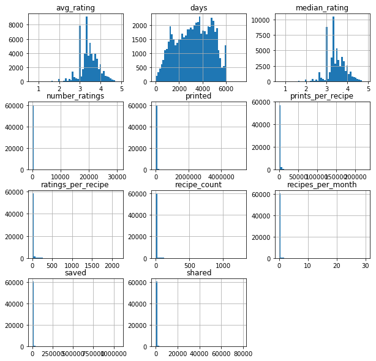

```python
# How is the data distributed?
_ = topusers.hist(bins=50, figsize=(10,10))
```

```python
# Show basic statistics (count, percentiles and measures of central value)
topusers.describe()
```

|  | recipe_count | printed | number_ratings | saved | shared | avg_rating | median_rating | days | ratings_per_recipe | recipes_per_month | prints_per_recipe |
| --- | --- | --- | --- | --- | --- | --- | --- | --- | --- | --- | --- |
| count | 60813.000000 | 6.081300e+04 | 60813.000000 | 6.081300e+04 | 60813.000000 | 60813.000000 | 60813.000000 | 60813.000000 | 60813.000000 | 60813.000000 | 60813.000000 |
| mean | 3.523654 | 9.269564e+03 | 40.307352 | 1.243083e+03 | 87.307928 | 3.447243 | 3.446364 | 3237.395557 | 9.708673 | 0.040528 | 1385.518382 |
| std | 16.601532 | 5.559476e+04 | 257.439141 | 8.752056e+03 | 641.879043 | 0.452135 | 0.457813 | 1474.217784 | 35.740514 | 0.263185 | 4013.154753 |
| min | 1.000000 | 0.000000e+00 | 1.000000 | 0.000000e+00 | 0.000000 | 0.690000 | 0.690000 | 0.000000 | 1.000000 | 0.005082 | 0.000000 |
| 25% | 1.000000 | 3.310000e+02 | 2.000000 | 2.700000e+01 | 0.000000 | 3.200000 | 3.200000 | 2045.000000 | 1.000000 | 0.008549 | 152.000000 |
| 50% | 1.000000 | 9.720000e+02 | 4.000000 | 8.700000e+01 | 5.000000 | 3.415000 | 3.400000 | 3330.000000 | 3.000000 | 0.014800 | 393.000000 |
| 75% | 2.000000 | 3.818000e+03 | 14.000000 | 3.990000e+02 | 28.000000 | 3.750000 | 3.750000 | 4485.000000 | 7.000000 | 0.028958 | 1164.000000 |
| max | 1279.000000 | 5.269036e+06 | 30612.000000 | 1.058164e+06 | 78844.000000 | 4.870000 | 4.870000 | 7348.000000 | 2165.000000 | 30.000000 | 227270.000000 |

The histograms show a high skewness in most attributes (number_ratings, saved, shared, printed, recipe_count). This means that there is a very large number of users that contribute only a few recipes or have collected only a few ratings/prints/etc, which is why the data is strongly skewed with regards to these attributes. At the same time, there is a small number of users that is highly active, publishing many recipes and collecting many ratings. This can be seen in the large difference between 75% percentile and maximum for these attributes.

We can see that more than 75% of all users have received an average rating of 3.2 stars (out of 5), but not a single user has received the maximum rating of 5 stars, which provides us with a rather balanced distribution. The attributes recipe_count, clicks_per_recipe and number_votes show their skewness in the differences between mean and median (or between 75% percentile and maximum). Still, these attributes could be used for further insights, as they are not capped like avg_rating.

An approach of handling the skewness could be to transform and normalise the data fields by using a logarithmic transformation and then shifting the mean to zero to achieve a certain degree of normalisation. Normal in this case means that a distributions skewness and kurtosis move towards those of a normal distribution. Unfortunately, transformations can strongly reduce the interpretability of attributes, as the more these values are transformed, the further away they are from their easy-to-understand real value, which a reader can relate to.

```python
# Which users have the highest "print efficiency" (collected most prints per recipe)?
user_efficiency = topusers.sort_values(by='prints_per_recipe',ascending=False)
top_efficiency = user_efficiency.loc[user_efficiency["recipe_count"]>=5]  # with more than 5 recipes published
top_efficiency.head(10)
```

|  | recipe_count | printed | number_ratings | saved | shared | avg_rating | median_rating | days | ratings_per_recipe | recipes_per_month | prints_per_recipe |
| --- | --- | --- | --- | --- | --- | --- | --- | --- | --- | --- | --- |
| Chililinde | 6 | 446721 | 2042 | 43283 | 4375 | 3.340000 | 3.28 | 5887 | 340.333333 | 0.030571 | 63817.285714 |
| lone_bohne | 13 | 847796 | 6534 | 105250 | 7697 | 4.292308 | 4.42 | 5651 | 502.615385 | 0.069002 | 60556.857143 |
| ulli1990 | 6 | 403881 | 1115 | 31683 | 1517 | 3.988333 | 4.00 | 3547 | 185.833333 | 0.050733 | 57697.285714 |
| Katja242 | 6 | 358191 | 2074 | 53220 | 2198 | 3.955000 | 3.80 | 4621 | 345.666667 | 0.038944 | 51170.142857 |
| VanessaR | 16 | 810880 | 680 | 27932 | 3898 | 3.905000 | 4.04 | 5845 | 42.500000 | 0.082107 | 47698.823529 |
| simoon | 10 | 487811 | 734 | 30691 | 5462 | 3.942000 | 3.95 | 7348 | 73.400000 | 0.040822 | 44346.454545 |
| daisylein | 5 | 238430 | 510 | 12454 | 1460 | 3.694000 | 4.25 | 4829 | 102.000000 | 0.031056 | 39738.333333 |
| Kochschnuck | 8 | 352437 | 2332 | 45896 | 3792 | 3.906250 | 3.89 | 4105 | 291.500000 | 0.058451 | 39159.666667 |
| KnuddelBAERbel | 8 | 337952 | 711 | 20564 | 366 | 3.591250 | 3.60 | 4763 | 88.875000 | 0.050378 | 37550.222222 |
| etikette | 9 | 365197 | 1635 | 46829 | 2424 | 3.731111 | 3.71 | 4593 | 181.666667 | 0.058772 | 36519.700000 |

We can see that the top users all have less than 20 recipes in total and less than 0.1 recipes per month published. Still, these users have published recipes that have been printed quite often, which indicates popularity and a certain quality. We can take a look at the histograms for a small subset of users and we will see, that there is still an exponential distribution in most of the attributes:

```
array([[<matplotlib.axes._subplots.AxesSubplot object at 0x7fa075c53518>,
        <matplotlib.axes._subplots.AxesSubplot object at 0x7fa0755c5550>]], dtype=object)
```

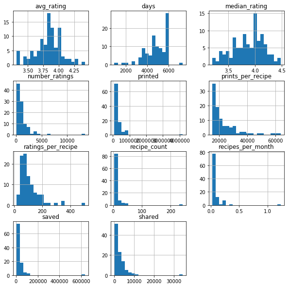

```python
# Histograms for top 100 efficient users
top_efficiency.head(100).hist(bins=20, figsize=(10,10))
```

Now we can look at the top users from a different perspective: their ability to collect rating votes for their recipes.

```python
# Sort by average votes
vote_efficiency = topusers.sort_values(by='ratings_per_recipe',ascending=False)
vote_efficiency.head(10)
```

|  | recipe_count | printed | number_ratings | saved | shared | avg_rating | median_rating | days | ratings_per_recipe | recipes_per_month | prints_per_recipe |
| --- | --- | --- | --- | --- | --- | --- | --- | --- | --- | --- | --- |
| tillek | 1 | 250282 | 2165 | 40037 | 1480 | 4.65 | 4.65 | 4098 | 2165.0 | 0.007319 | 125141.000000 |
| Iceblock | 1 | 394646 | 1633 | 33136 | 1465 | 4.60 | 4.60 | 3431 | 1633.0 | 0.008741 | 197323.000000 |
| SüßeVersuchung | 1 | 131966 | 1378 | 20094 | 1042 | 4.57 | 4.57 | 3384 | 1378.0 | 0.008863 | 65983.000000 |
| hexe107810 | 2 | 544037 | 2669 | 55143 | 4339 | 4.11 | 4.11 | 4001 | 1334.5 | 0.014993 | 181345.666667 |
| sweetgwendoline | 1 | 182295 | 1229 | 22911 | 1611 | 4.82 | 4.82 | 4850 | 1229.0 | 0.006184 | 91147.500000 |
| Ute123 | 1 | 222971 | 1207 | 17296 | 1312 | 4.64 | 4.64 | 4695 | 1207.0 | 0.006388 | 111485.500000 |
| blueJay | 1 | 196298 | 1140 | 36943 | 207 | 4.69 | 4.69 | 3226 | 1140.0 | 0.009297 | 98149.000000 |
| michaellange | 1 | 454540 | 1066 | 26569 | 5973 | 4.67 | 4.67 | 5423 | 1066.0 | 0.005531 | 227270.000000 |
| evelyn2 | 1 | 113528 | 1050 | 16039 | 1628 | 4.58 | 4.58 | 4351 | 1050.0 | 0.006893 | 56764.000000 |
| Jehuty | 1 | 103081 | 980 | 15458 | 43 | 4.81 | 4.81 | 4268 | 980.0 | 0.007027 | 51540.500000 |

### Correlations

In the next step, we can build a scatter matrix to see how these features that we have just created:

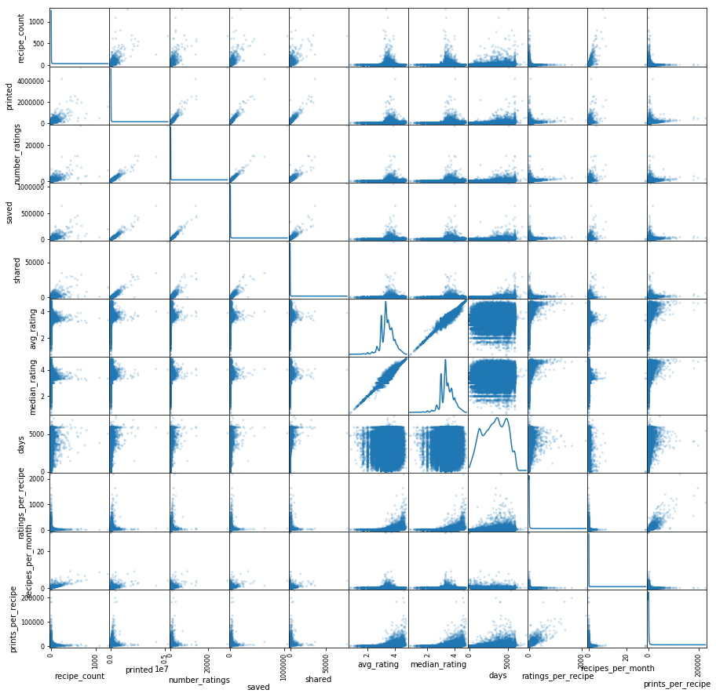

```python
from pandas.plotting import scatter_matrix
_ = scatter_matrix(vote_efficiency, alpha=0.2, figsize=(15, 15), diagonal='kde')
```

We can see that there seems to be a high correlation between the pair combinations of printed, number_ratings, saved and shared. The dependencies between avg_rating and median_rating, as well as recipes per month and recipe count are understandable, as those attribute pairs are closely related.

To analyse the dependencies in more detail, we can use a correlation coefficient to measure linear dependency between two attributes. The package scipy provides multiple functions for this purpose. We can start by using the Pearson's r, which is the most commonly used correlation coefficient:

```python
# Compute all Pearson r's and their p-Value, which are then stored in lists:
from scipy.stats.stats import pearsonr

def calculate_pearson(df):
    pear = []
    pearp = []
    for i in df:
        pear_i = []
        pearp_i = []
        for j in df:
            pear_i.append(pearsonr(df[i], df[j])[0])
            pearp_i.append(pearsonr(df[i], df[j])[1])
        pear.append(pear_i)
        pearp.append(pearp_i)
    return pear, pearp
```

```python
pear, pearp = calculate_pearson(vote_efficiency)
peardf = pd.DataFrame(pear, columns=vote_efficiency.columns, index=vote_efficiency.columns)
peardf
```

|  | recipe_count | printed | number_ratings | saved | shared | avg_rating | median_rating | days | ratings_per_recipe | recipes_per_month | prints_per_recipe |
| --- | --- | --- | --- | --- | --- | --- | --- | --- | --- | --- | --- |
| recipe_count | 1.000000 | 0.703787 | 0.682485 | 0.678412 | 0.614743 | 0.020660 | 0.018687 | 0.080167 | 0.010276 | 0.489506 | 0.045059 |
| printed | 0.703787 | 1.000000 | 0.958459 | 0.967899 | 0.939605 | 0.100828 | 0.102952 | 0.142937 | 0.195540 | 0.296198 | 0.299042 |
| number_ratings | 0.682485 | 0.958459 | 1.000000 | 0.979754 | 0.919176 | 0.104952 | 0.106982 | 0.123652 | 0.243872 | 0.296207 | 0.280326 |
| saved | 0.678412 | 0.967899 | 0.979754 | 1.000000 | 0.927822 | 0.091794 | 0.094261 | 0.120813 | 0.174535 | 0.288755 | 0.229482 |
| shared | 0.614743 | 0.939605 | 0.919176 | 0.927822 | 1.000000 | 0.080989 | 0.084648 | 0.153458 | 0.158679 | 0.221331 | 0.239864 |
| avg_rating | 0.020660 | 0.100828 | 0.104952 | 0.091794 | 0.080989 | 1.000000 | 0.989553 | 0.106742 | 0.320327 | 0.003960 | 0.331330 |
| median_rating | 0.018687 | 0.102952 | 0.106982 | 0.094261 | 0.084648 | 0.989553 | 1.000000 | 0.109740 | 0.317436 | 0.002148 | 0.329687 |
| days | 0.080167 | 0.142937 | 0.123652 | 0.120813 | 0.153458 | 0.106742 | 0.109740 | 1.000000 | 0.145485 | -0.065815 | 0.225596 |
| ratings_per_recipe | 0.010276 | 0.195540 | 0.243872 | 0.174535 | 0.158679 | 0.320327 | 0.317436 | 0.145485 | 1.000000 | -0.007550 | 0.833950 |
| recipes_per_month | 0.489506 | 0.296198 | 0.296207 | 0.288755 | 0.221331 | 0.003960 | 0.002148 | -0.065815 | -0.007550 | 1.000000 | 0.001857 |
| prints_per_recipe | 0.045059 | 0.299042 | 0.280326 | 0.229482 | 0.239864 | 0.331330 | 0.329687 | 0.225596 | 0.833950 | 0.001857 | 1.000000 |

```python
pearpdf = pd.DataFrame(pearp, columns=vote_efficiency.columns, index=vote_efficiency.columns)
pearpdf
```

|  | recipe_count | printed | number_ratings | saved | shared | avg_rating | median_rating | days | ratings_per_recipe | recipes_per_month | prints_per_recipe |
| --- | --- | --- | --- | --- | --- | --- | --- | --- | --- | --- | --- |
| recipe_count | 0.000000e+00 | 0.000000e+00 | 0.000000e+00 | 0.000000e+00 | 0.000000e+00 | 3.484813e-07 | 4.055345e-06 | 2.927379e-87 | 1.127068e-02 | 0.000000e+00 | 1.037044e-28 |
| printed | 0.000000e+00 | 0.000000e+00 | 0.000000e+00 | 0.000000e+00 | 0.000000e+00 | 3.740279e-137 | 6.149719e-143 | 5.895149e-275 | 0.000000e+00 | 0.000000e+00 | 0.000000e+00 |
| number_ratings | 0.000000e+00 | 0.000000e+00 | 0.000000e+00 | 0.000000e+00 | 0.000000e+00 | 1.698336e-148 | 2.994100e-154 | 9.043878e-206 | 0.000000e+00 | 0.000000e+00 | 0.000000e+00 |
| saved | 0.000000e+00 | 0.000000e+00 | 0.000000e+00 | 0.000000e+00 | 0.000000e+00 | 6.431382e-114 | 4.823893e-120 | 1.868851e-196 | 0.000000e+00 | 0.000000e+00 | 0.000000e+00 |
| shared | 0.000000e+00 | 0.000000e+00 | 0.000000e+00 | 0.000000e+00 | 0.000000e+00 | 5.031969e-89 | 4.212273e-97 | 4.314679e-317 | 0.000000e+00 | 0.000000e+00 | 0.000000e+00 |
| avg_rating | 3.484813e-07 | 3.740279e-137 | 1.698336e-148 | 6.431382e-114 | 5.031969e-89 | 0.000000e+00 | 0.000000e+00 | 1.456928e-153 | 0.000000e+00 | 3.287447e-01 | 0.000000e+00 |
| median_rating | 4.055345e-06 | 6.149719e-143 | 2.994100e-154 | 4.823893e-120 | 4.212273e-97 | 0.000000e+00 | 0.000000e+00 | 3.013544e-162 | 0.000000e+00 | 5.963763e-01 | 0.000000e+00 |
| days | 2.927379e-87 | 5.895149e-275 | 9.043878e-206 | 1.868851e-196 | 4.314679e-317 | 1.456928e-153 | 3.013544e-162 | 0.000000e+00 | 7.092172e-285 | 2.324970e-59 | 0.000000e+00 |
| ratings_per_recipe | 1.127068e-02 | 0.000000e+00 | 0.000000e+00 | 0.000000e+00 | 0.000000e+00 | 0.000000e+00 | 0.000000e+00 | 7.092172e-285 | 0.000000e+00 | 6.263160e-02 | 0.000000e+00 |
| recipes_per_month | 0.000000e+00 | 0.000000e+00 | 0.000000e+00 | 0.000000e+00 | 0.000000e+00 | 3.287447e-01 | 5.963763e-01 | 2.324970e-59 | 6.263160e-02 | 0.000000e+00 | 6.469261e-01 |
| prints_per_recipe | 1.037044e-28 | 0.000000e+00 | 0.000000e+00 | 0.000000e+00 | 0.000000e+00 | 0.000000e+00 | 0.000000e+00 | 0.000000e+00 | 0.000000e+00 | 6.469261e-01 | 0.000000e+00 |

The pairwise correlations can confirm the assumptions we have taken from the scatter matrix above. It is quite interesting that avg/median rating and days do not seem to correlate with any of the popularity metrics.

It has to be noted that the Pearson r assumes normal distribution and only measure linear dependence between values. To achieve a more general view, we should calculate a different correlation coefficient for comparison: The Spearman's rho, which is a rank correlation coefficient, does measure how well the relationship between two attributes can be described with a monotonic function. This includes linear functions, but is not limited to them. (An alternative option to this would be Kendall's tau, which operates in a similar way.)

```python
from scipy.stats.stats import spearmanr
speardf = pd.DataFrame(spearmanr(vote_efficiency)[0], columns=vote_efficiency.columns, index=vote_efficiency.columns)
speardf
```

|  | recipe_count | printed | number_ratings | saved | shared | avg_rating | median_rating | days | ratings_per_recipe | recipes_per_month | prints_per_recipe |
| --- | --- | --- | --- | --- | --- | --- | --- | --- | --- | --- | --- |
| recipe_count | 1.000000 | 0.608600 | 0.657409 | 0.595341 | 0.463580 | 0.088267 | 0.074524 | 0.217915 | 0.326081 | 0.655824 | 0.421098 |
| printed | 0.608600 | 1.000000 | 0.866610 | 0.953555 | 0.819180 | 0.482709 | 0.466260 | 0.518729 | 0.771315 | 0.124436 | 0.967911 |
| number_ratings | 0.657409 | 0.866610 | 1.000000 | 0.892017 | 0.698472 | 0.603697 | 0.584284 | 0.396195 | 0.910559 | 0.260887 | 0.801856 |
| saved | 0.595341 | 0.953555 | 0.892017 | 1.000000 | 0.811203 | 0.516853 | 0.499772 | 0.519040 | 0.811955 | 0.113948 | 0.919312 |
| shared | 0.463580 | 0.819180 | 0.698472 | 0.811203 | 1.000000 | 0.331476 | 0.321804 | 0.751136 | 0.654561 | -0.126484 | 0.818245 |
| avg_rating | 0.088267 | 0.482709 | 0.603697 | 0.516853 | 0.331476 | 1.000000 | 0.983291 | 0.127600 | 0.719631 | -0.011848 | 0.534172 |
| median_rating | 0.074524 | 0.466260 | 0.584284 | 0.499772 | 0.321804 | 0.983291 | 1.000000 | 0.126513 | 0.702067 | -0.020499 | 0.519745 |
| days | 0.217915 | 0.518729 | 0.396195 | 0.519040 | 0.751136 | 0.127600 | 0.126513 | 1.000000 | 0.408966 | -0.517578 | 0.546796 |
| ratings_per_recipe | 0.326081 | 0.771315 | 0.910559 | 0.811955 | 0.654561 | 0.719631 | 0.702067 | 0.408966 | 1.000000 | -0.003884 | 0.803921 |
| recipes_per_month | 0.655824 | 0.124436 | 0.260887 | 0.113948 | -0.126484 | -0.011848 | -0.020499 | -0.517578 | -0.003884 | 1.000000 | -0.043708 |
| prints_per_recipe | 0.421098 | 0.967911 | 0.801856 | 0.919312 | 0.818245 | 0.534172 | 0.519745 | 0.546796 | 0.803921 | -0.043708 | 1.000000 |

```python
from scipy.stats.stats import spearmanr
spearpdf = pd.DataFrame(spearmanr(vote_efficiency)[1], columns=vote_efficiency.columns, index=vote_efficiency.columns)
spearpdf
```

|  | recipe_count | printed | number_ratings | saved | shared | avg_rating | median_rating | days | ratings_per_recipe | recipes_per_month | prints_per_recipe |
| --- | --- | --- | --- | --- | --- | --- | --- | --- | --- | --- | --- |
| recipe_count | 0.000000e+00 | 0.000000e+00 | 0.0 | 0.000000e+00 | 0.000000e+00 | 1.902467e-105 | 1.242792e-75 | 0.000000e+00 | 0.000000 | 0.000000e+00 | 0.000000e+00 |
| printed | 0.000000e+00 | 0.000000e+00 | 0.0 | 0.000000e+00 | 0.000000e+00 | 0.000000e+00 | 0.000000e+00 | 0.000000e+00 | 0.000000 | 2.217451e-208 | 0.000000e+00 |
| number_ratings | 0.000000e+00 | 0.000000e+00 | 0.0 | 0.000000e+00 | 0.000000e+00 | 0.000000e+00 | 0.000000e+00 | 0.000000e+00 | 0.000000 | 0.000000e+00 | 0.000000e+00 |
| saved | 0.000000e+00 | 0.000000e+00 | 0.0 | 0.000000e+00 | 0.000000e+00 | 0.000000e+00 | 0.000000e+00 | 0.000000e+00 | 0.000000 | 7.486773e-175 | 0.000000e+00 |
| shared | 0.000000e+00 | 0.000000e+00 | 0.0 | 0.000000e+00 | 0.000000e+00 | 0.000000e+00 | 0.000000e+00 | 0.000000e+00 | 0.000000 | 2.775720e-215 | 0.000000e+00 |
| avg_rating | 1.902467e-105 | 0.000000e+00 | 0.0 | 0.000000e+00 | 0.000000e+00 | 0.000000e+00 | 0.000000e+00 | 4.295996e-219 | 0.000000 | 3.480843e-03 | 0.000000e+00 |
| median_rating | 1.242792e-75 | 0.000000e+00 | 0.0 | 0.000000e+00 | 0.000000e+00 | 0.000000e+00 | 0.000000e+00 | 2.220757e-215 | 0.000000 | 4.293399e-07 | 0.000000e+00 |
| days | 0.000000e+00 | 0.000000e+00 | 0.0 | 0.000000e+00 | 0.000000e+00 | 4.295996e-219 | 2.220757e-215 | 0.000000e+00 | 0.000000 | 0.000000e+00 | 0.000000e+00 |
| ratings_per_recipe | 0.000000e+00 | 0.000000e+00 | 0.0 | 0.000000e+00 | 0.000000e+00 | 0.000000e+00 | 0.000000e+00 | 0.000000e+00 | 0.000000 | 3.382063e-01 | 0.000000e+00 |
| recipes_per_month | 0.000000e+00 | 2.217451e-208 | 0.0 | 7.486773e-175 | 2.775720e-215 | 3.480843e-03 | 4.293399e-07 | 0.000000e+00 | 0.338206 | 0.000000e+00 | 4.121102e-27 |
| prints_per_recipe | 0.000000e+00 | 0.000000e+00 | 0.0 | 0.000000e+00 | 0.000000e+00 | 0.000000e+00 | 0.000000e+00 | 0.000000e+00 | 0.000000 | 4.121102e-27 | 0.000000e+00 |

The evaluation with Spearman's rho confirms the correlations that were found with Pearson's r and even increases their value. However, some coefficients are slightly smaller now, whereas other dependencies that Pearson's r did not reveal now seem clearly stronger: Interestingly, the pairwise correlations for ratings (avg, median and per month) and the other popularity metrics (printed, shared, saved) now show much higher values with 0.48 to 0.6 instead of 0.08 to 0.12 (with Pearson's r). We can also see now that there is some dependency between days and shared, which suggests that the number a user's recipes are shared more likely accumulates over time than the other popularity metrics.

The columns printed and printed_per_recipe have a very high pairwise correlation and very similar dependencies with the other variables, which means that we could drop printed_per_recipe for dimensionality reduction, as it does not provide new information. The same is valid for avg_rating and med_rating.

As we have exponential distributions (shown by the histograms and kernel density estimations), we can try logarithmic transformations to normalise the attributes.

### Logarithmic transformation

Except for avg_rating, med_rating and days, all attributes could be transformed with the goal of normalising them. (This will not be performed for printed_per_recipe, because it is enough to do it for printed, as explained above.)

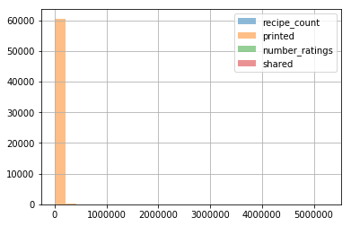

```python
# Looking at the histograms in a single graph
import numpy as np
vote_efficiency["recipe_count"].hist(bins=25, alpha=0.5, label="recipe_count")  # blue
vote_efficiency["printed"].hist(bins=25, alpha=0.5, label="printed")  # orange/yellow
vote_efficiency["number_ratings"].hist(bins=25, alpha=0.5, label="number_ratings")  # green
vote_efficiency["shared"].hist(bins=25, alpha=0.5, label="shared")  # red
plt.legend()
plt.show()
```

Before log transformation, we need to eliminate zero values in the data.

```python
def add_one(x):
    return x+1
```

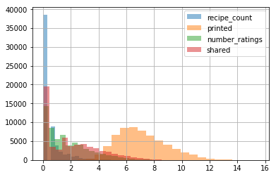

```python
# How do the histograms look if we log transform all attributes?
users_transformed = pd.DataFrame(vote_efficiency)
users_transformed["recipe_count"].apply(np.log).hist(bins=25, alpha=0.5, label="recipe_count")  # still exponential
users_transformed["printed"].apply(add_one).apply(np.log).hist(bins=25, alpha=0.5, label="printed")
users_transformed["number_ratings"].apply(np.log).hist(bins=25, alpha=0.5, label="number_ratings")
users_transformed["shared"].apply(add_one).apply(np.log).hist(bins=25, alpha=0.5, label="shared")
plt.legend()
plt.show()
```

As we can see, logarithmic transformations do not help much, except in the case of printed.

The attributes recipe_count, number_ratings and shared still show an exponential distribution, even after transformation.

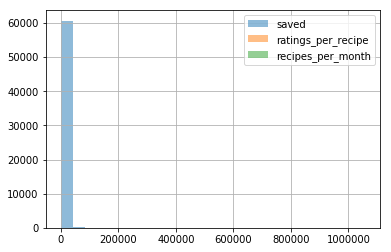

```python
vote_efficiency['saved'].hist(bins=25, alpha=0.5, label="saved")
vote_efficiency['ratings_per_recipe'].hist(bins=25, alpha=0.5, label="ratings_per_recipe")
vote_efficiency['recipes_per_month'].hist(bins=25, alpha=0.5, label="recipes_per_month")
plt.legend()
plt.show()
```

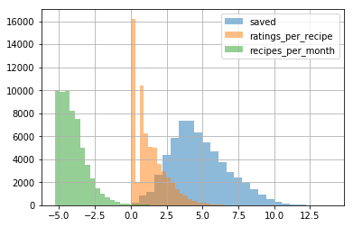

```python
users_transformed = pd.DataFrame(vote_efficiency)
users_transformed['saved'].apply(add_one).apply(np.log).hist(bins=25, alpha=0.5, label="saved")
users_transformed['ratings_per_recipe'].apply(np.log).hist(bins=25, alpha=0.5, label="ratings_per_recipe")
users_transformed['recipes_per_month'].apply(np.log).hist(bins=25, alpha=0.5, label="recipes_per_month")
plt.legend()
plt.show()
```

We can see that the attributes ratings_per_recipe and recipes_per_month still have an exponential distribution, even after logarithmic transofmration. The attribute saved could be transformed to have much lower skewness.

##### How can we use this knowledge about the data distributions?

We now know how the different attributes are distributed. This means that we can we can select the recipes that are in the top 5% of the data with respect to their value in each of these attributes. Using that knowledge, we can look for the top 5% recipes regarding their popularity in terms of clicks, votes and favorites. Additionally, when we receive new user data, we can assess their success based on the distributions that we have calculated. Selecting such subsets from a distribution is of course easier if the data resembles a rather normal distribution, as then the position of each data point in relation to the data's mean and percentiles is more easily understandable.

### Summary

We have found multiple ways to find users that have been successful in the community: by publishing a high amount of recipes or very popular ones. There are simple ways to find users that have collected high popularity metrics in total or with only a few recipes, being quite efficient in that regard. From a business perspective, the overview of efficient users can be used to find recipes that provide a consistently high quality (by only selecting the recipes that come from users that perform well consistently), which is important to achieve a certain quality of service.

One simple way to find outstanding users is to look for outliers in this data. For example, we have shown that the popularity metrics more or less have the same meaning, seeing their pairwise correlation coefficients. However, there will be users that have collected extraordinarily high number of "prints" for their recipes, thus making them an outlier in this comparison. These users most probably will have published more successful recipes than others. Such users can be found looking for data points that lie above the regression line and can be reduced to a few by using margins or an error metric. As an example, users that strongly deviate from the average will have a high mean squared error (MSE). These can be either the very good or very bad users, depending on the direction of the error. Thus, we can easily find the users that are interesting for our business.

Of course, we could just query for the recipes that have the most prints or highest rating, and we would probably find the most popular recipes. However, this extensive statistical analysis helps us to identify users that have been providing good recipes consistently, even if not all of them are among the top recipes regarding their total clicks. This means that our analysis can be very valuable to find recipes with high and consistent quality.

Additionally, we can find users who might not have published successful mainstream recipes (like pancakes), but instead interesting niche foods, e.g. asian vegan cuisine, on a consistent quality level, if we do not only search for the highest clicks, but instead a consistent performance across multiple recipes.

### Single user analysis

Now, we want to apply our knowledge and pick one of these users seen in our analysis above. First, we need to identify users that are in the top few of the multiple DataFrame that have been created. Then, we can take a detailed look at the recipes he/she has published.

Show intersection of top 1000 in both, vote_efficiency and topusers:

```python
# Intersection of top 1000 users in both dataframes:
intersect = vote_efficiency[:1000].index.intersection(topusers[:1000].index)
intersect
```

```
Index(['jesusfreak', 'Christine_R', 'sandy07', 'Delphinella'], dtype='object')
```

```python
topusers.loc[(intersect.tolist())].loc[topusers['recipe_count'] <= 100].sort_values(by='printed',ascending=False)
```

|  | recipe_count | printed | number_ratings | saved | shared | avg_rating | median_rating | days | ratings_per_recipe | recipes_per_month | prints_per_recipe |
| --- | --- | --- | --- | --- | --- | --- | --- | --- | --- | --- | --- |
| jesusfreak | 37 | 788232 | 4188 | 94272 | 8212 | 3.985405 | 4.06 | 4539 | 113.189189 | 0.244493 | 20742.947368 |
| sandy07 | 46 | 748658 | 4069 | 120890 | 8637 | 4.159130 | 4.32 | 3981 | 88.456522 | 0.346560 | 15928.893617 |
| Christine_R | 32 | 635287 | 3495 | 105973 | 7743 | 4.424375 | 4.48 | 4076 | 109.218750 | 0.235467 | 19251.121212 |
| Delphinella | 26 | 386978 | 2292 | 59359 | 3013 | 3.804615 | 4.00 | 4742 | 88.153846 | 0.164453 | 14332.518519 |

We can see that user 'Christine_R' has been quite successful with the 32 recipes that she has published, also reaching an average rating of 4.42.

```python
# Show the top 10 recipes written by user "Christine_R":

chefdf.loc[chefdf['user'] == 'Christine_R'].sort_values(by='printed',ascending=False).head(10)
```

|  | avg_rating | date | day | difficulty | ingredients | month | name | number_ratings | preparation | printed | saved | shared | subtitle | user | user_date | year |
| --- | --- | --- | --- | --- | --- | --- | --- | --- | --- | --- | --- | --- | --- | --- | --- | --- |
| 2517 | 4.55 | 2007-11-27 | 27 | normal | [300g, Mehl, 200g, Butter(nichtganzkalt,inklei... | 11 | Linzer Augen | 308 | Das Mehl mit den übrigen Zutaten in eine Rühr... | 64759 | 8620 | 729 | werden bei uns in Linz das ganze Jahr über geg... | Christine_R | 2007-01-02 | 2007 |
| 1107 | 4.62 | 2007-11-20 | 20 | normal | [230g, Mehl, 200g, Butter, 70g, Stärkemehl(Mai... | 11 | Linzer Kipferl | 209 | Alle Zutaten rasch mit einer Küchenmaschine z... | 62157 | 9548 | 705 | zart-mürbes Spritzgebäck, schmeckt nicht nur z... | Christine_R | 2007-01-02 | 2007 |
| 4879 | 4.48 | 2008-11-04 | 04 | normal | [600g, Birne(n),reife,z.B.WilliamsChrist, 4EL,... | 11 | Birnen - Schokolade - Kuchen | 241 | Die Birnen schälen, vierteln und das Kerngehä... | 53488 | 6264 | 439 | feine Kombination von Birnen und Schokolade | Christine_R | 2007-01-02 | 2008 |
| 128445 | 4.67 | 2007-11-20 | 20 | normal | [500g, Roggenvollkornmehl, 300g, Dinkelvollkor... | 11 | Omas Lebkuchen | 293 | Den Honig mit dem Zucker bei kleiner Flamme u... | 49778 | 7394 | 560 | besonders aromatisch, ist sofort weich | Christine_R | 2007-01-02 | 2007 |
| 1401 | 4.60 | 2008-04-15 | 15 | normal | [300g, Mehl, 200g, Butter,(ca.15Min.vorVerarbe... | 04 | Apfelkuchen aus Hefemürbteig | 233 | Die Hefe mit dem Puderzucker und der kalten M... | 43334 | 5444 | 331 | herrlich aromatischer und zartmürber Apfelkuchen | Christine_R | 2007-01-02 | 2008 |
| 4030 | 4.51 | 2007-07-09 | 09 | normal | [5, 125g, Zucker,feinen, 1EL, Vanillezucker, e... | 07 | Biskuitrolle mit Erdbeer-Quark-Sahne Füllung | 113 | Tipp:Ich bereite immer zuerst die Füllung vor... | 38416 | 3846 | 296 | auch mit Himbeeren sehr lecker - ein Genuss fü... | Christine_R | 2007-01-02 | 2007 |
| 2106 | 4.57 | 2007-05-23 | 23 | normal | [300g, Mehl, 150g, 150g, 220g, Zucker,fein, 1,... | 05 | Linzer Torte aus Mürbteig | 141 | Mehl und Butter mit der Hand gut abbröseln un... | 33315 | 4493 | 326 | Familienrezept aus Linz | Christine_R | 2007-01-02 | 2007 |
| 5029 | 4.47 | 2007-02-23 | 23 | normal | [500g, Mehl,(ichnehmehalbDinkel-halbWeizenmehl... | 02 | Apfelkuchen gedeckt | 183 | Für den Teig das Mehl mit dem Backpulver sieb... | 30896 | 4171 | 517 | saftig-aromatische Fülle | Christine_R | 2007-01-02 | 2007 |
| 7115 | 4.42 | 2007-05-27 | 27 | simpel | [250g, 140g, Butter, 100g, Zucker, 1Pkt., Vani... | 05 | Erdbeermuffins | 159 | Backrohr auf 180 Grad Umluft vorheizen.\rIn j... | 26464 | 5160 | 297 | sehr lecker und fruchtig - ideal auch mit Himb... | Christine_R | 2007-01-02 | 2007 |
| 5588 | 4.46 | 2008-04-16 | 16 | normal | [140g, Mehl, 70g, Speisestärke, 75g, Puderzuck... | 04 | Apfelkuchen mit Amaretto - Sahne - Guss | 136 | Alle Zutaten für den Mürbteig rasch miteinand... | 22573 | 4058 | 257 | einfach, schnell gemacht und sehr lecker | Christine_R | 2007-01-02 | 2008 |

```python
# Provide meta information about user "Christine_R"
chefdf.loc[chefdf['user'] == "Christine_R"].info()
```

```
<class 'pandas.core.frame.DataFrame'>
Int64Index: 32 entries, 477 to 128445
Data columns (total 16 columns):
avg_rating        32 non-null float64
date              32 non-null datetime64[ns]
day               32 non-null object
difficulty        32 non-null object
ingredients       32 non-null object
month             32 non-null object
name              32 non-null object
number_ratings    32 non-null int64
preparation       32 non-null object
printed           32 non-null int64
saved             32 non-null int64
shared            32 non-null int64
subtitle          28 non-null object
user              32 non-null object
user_date         32 non-null datetime64[ns]
year              32 non-null object
dtypes: datetime64[ns](2), float64(1), int64(4), object(9)
memory usage: 4.2+ KB
```

```python
vote_efficiency.loc[vote_efficiency.index == 'Christine_R']
```

|  | recipe_count | printed | number_ratings | saved | shared | avg_rating | median_rating | days | ratings_per_recipe | recipes_per_month | prints_per_recipe |
| --- | --- | --- | --- | --- | --- | --- | --- | --- | --- | --- | --- |
| Christine_R | 32 | 635287 | 3495 | 105973 | 7743 | 4.424375 | 4.48 | 4076 | 109.21875 | 0.235467 | 19251.121212 |

User "Christine_R" has uploaded 32 recipes, of which he/she delivered 28 with a complete data set including the subtitle. This user apparently only has published recipes for desserts and cakes during 2007 and 2008. Her recipes have received high popularity ratings consistently.

We can now compare these insights with the data of user "Chililinde", which is one of the most efficient users with the highest value in printed_per_recipe, as shown above:

```python
chefdf.loc[chefdf['user'] == 'Chililinde'].sort_values(by='printed',ascending=False)
```

|  | avg_rating | date | day | difficulty | ingredients | month | name | number_ratings | preparation | printed | saved | shared | subtitle | user | user_date | year |
| --- | --- | --- | --- | --- | --- | --- | --- | --- | --- | --- | --- | --- | --- | --- | --- | --- |
| 790 | 4.65 | 2002-11-19 | 19 | normal | [560g, Mehl, 160g, Zucker, 400g, ButteroderMar... | 11 | Vanillekipferl | 2011 | Mehl, Zucker und in kleine Stücke geschnitten... | 440263 | 42120 | 4259 | Generationsrezept | Chililinde | 2002-01-17 | 2002 |
| 91617 | 3.56 | 2001-05-18 | 18 | simpel | [1, /, Liter, Buttermilch, 2, 2, Pellkartoffel... | 05 | Okroschka | 7 | Alles miteinander mischen und mit ein wenig S... | 2324 | 437 | 33 | ... eine Suppe für heisse Tage aus Rußland | Chililinde | 2002-01-17 | 2001 |
| 167716 | 3.06 | 2001-11-28 | 28 | simpel | [3EL, Milch, 2EL, Kakaopulver, 2EL, Margarine,... | 11 | Kakao-Häufchen | 15 | Milch, Kakao, Margarine und Zucker vermischen... | 2246 | 539 | 54 | None | Chililinde | 2002-01-17 | 2001 |
| 108901 | 3.50 | 2002-12-11 | 11 | normal | [1kg, Fleisch(Ziegenfleisch), 1, Paprikaschote... | 12 | Ziegen - Schaschlik | 2 | Fleisch in Würfel schneiden. Aus Olivenöl, Sa... | 847 | 34 | 5 | None | Chililinde | 2002-01-17 | 2002 |
| 215946 | 2.60 | 2002-12-11 | 11 | normal | [1kg, 125ml] | 12 | Lammscheiben vom Grill | 3 | Lammfleisch (Hals oder Bug) in Scheiben schne... | 571 | 35 | 5 | None | Chililinde | 2002-01-17 | 2002 |
| 209678 | 2.67 | 2001-11-28 | 28 | normal | [100g, Erdnüsse,60ghacken,40gzumVerzieren, 200... | 11 | Erdnußstangen | 4 | Alles zu einem Teig verkneten, zur Kugel form... | 470 | 118 | 19 | None | Chililinde | 2002-01-17 | 2001 |

```python
vote_efficiency.loc[vote_efficiency.index == 'Chililinde']
```

|  | recipe_count | printed | number_ratings | saved | shared | avg_rating | median_rating | days | ratings_per_recipe | recipes_per_month | prints_per_recipe |
| --- | --- | --- | --- | --- | --- | --- | --- | --- | --- | --- | --- |
| Chililinde | 6 | 446721 | 2042 | 43283 | 4375 | 3.34 | 3.28 | 5887 | 340.333333 | 0.030571 | 63817.285714 |

From a business perspective, we should aim to provide a mix of both worlds, having the selection of extremely popular recipes like pancakes and kötbullar, but at the same time enriching the recipe offer by high-quality and consistent recipes.

## Recipes

Now we can analyse further aspects of the recipe database, apart from the users. There are still multiple data fields that can provide interesting information. Aside from general statistics for creating an overview, the recipe titles and lists of ingredients provide text fields that could be "mined" for useful insights.

### Overview

We can first take a look at the simple statistics:

- Which recipes have collected the most prints?

```python
# Show top recipes according to clicks
clickdf = pd.DataFrame(chefdf.sort_values(by='printed',ascending=False))
clickdf.head(10)
```

|  | avg_rating | date | day | difficulty | ingredients | month | name | number_ratings | preparation | printed | saved | shared | subtitle | user | user_date | year |
| --- | --- | --- | --- | --- | --- | --- | --- | --- | --- | --- | --- | --- | --- | --- | --- | --- |
| 3169 | 4.53 | 2002-07-08 | 08 | simpel | [12große, Pfeffer,frischgemahlen, ButteroderMa... | 07 | Schnitzelpfanne | 164 | Schnitzel waschen, trocken tupfen, mit Salz u... | 607961 | 10407 | 1531 | None | VanessaR | 2002-02-28 | 2002 |
| 384 | 4.68 | 2005-01-06 | 06 | normal | [800g, Hokkaidokürbis(se),geputztgewogen, 600g... | 01 | Kürbissuppe mit Ingwer und Kokosmilch | 2241 | Kürbis, Möhren, Ingwer und Zwiebel schälen un... | 564662 | 38837 | 5079 | None | UlrikeM | 2004-08-03 | 2005 |
| 1083 | 4.62 | 2007-04-21 | 21 | normal | [500g, 1, 2, 1Bund, PetersilieoderTK, 1EL, Tom... | 04 | Lasagne | 2661 | Ragout Bolognese:In einem Topf das Olivenöl e... | 538629 | 54739 | 4253 | wie beim Italiener | hexe107810 | 2007-03-18 | 2007 |
| 531 | 4.67 | 2003-09-06 | 06 | simpel | [3, Eigelb, 75g, Zucker, 40ml, Amaretto, 500g,... | 09 | Tiramisu | 1066 | Das Eigelb in eine Schüssel (Messbecher) gebe... | 454540 | 26569 | 5973 | None | michaellange | 2003-04-26 | 2003 |
| 790 | 4.65 | 2002-11-19 | 19 | normal | [560g, Mehl, 160g, Zucker, 400g, ButteroderMar... | 11 | Vanillekipferl | 2011 | Mehl, Zucker und in kleine Stücke geschnitten... | 440263 | 42120 | 4259 | Generationsrezept | Chililinde | 2002-01-17 | 2002 |
| 619 | 4.66 | 2008-02-23 | 23 | simpel | [500g, 3Stange/n, Lauch, 250g, Schmelzkäse, 1B... | 02 | Käse-Lauch-Suppe mit Hackfleisch | 1670 | Den Ofen auf 175° C vorheizen. Die Baguettes ... | 415202 | 38376 | 1777 | None | Nitseltrik | 2006-09-26 | 2008 |
| 3328 | 4.52 | 2008-09-30 | 30 | normal | [800g, 2, Chilischote(n),rote, 2große, 1Zehe/n... | 09 | Chili con Carne | 1069 | Die Zwiebeln und den Knoblauch würfeln und in... | 396069 | 30618 | 1467 | mein Lieblings - Chili nach Jamies Art | ulli1990 | 2008-06-14 | 2008 |
| 1415 | 4.60 | 2008-11-20 | 20 | simpel | [4, 400g, Mehl, 100ml, 400ml, Milch, 1Pck., Va... | 11 | Pfannenkuchen / Pfannkuchen / Pfannekuchen / E... | 1633 | Die Eier trennen und das Eiweiß schaumig schl... | 394646 | 33136 | 1465 | None | Iceblock | 2008-10-08 | 2008 |
| 193 | 4.72 | 2007-07-06 | 06 | simpel | [1Becher, Schlagsahne,200g,geschlagen, 2Becher... | 07 | Mascarpone - Himbeer - Quark | 760 | Quark, Joghurt und Mascarpone gut mit dem Zuc... | 360780 | 25549 | 2118 | None | julialeini | 2003-10-28 | 2007 |
| 527 | 4.67 | 2008-03-30 | 30 | normal | [500g, 200g, 1Bund, Rucola, 1Glas, 1kl.Glas, O... | 03 | Italienischer Nudelsalat mit Rucola und getroc... | 548 | Die Nudeln al dente kochen und erkalten lasse... | 359186 | 21924 | 2525 | None | HeikoSüd | 2007-03-12 | 2008 |

We could do the same for:

- Which recipes have the highest number of saves?

```python
# Another example for sorting:
# Sort recipes by saved:
clickdf.sort_values(by=['saved'],ascending=[False]).head(10)
```

|  | avg_rating | date | day | difficulty | ingredients | month | name | number_ratings | preparation | printed | saved | shared | subtitle | user | user_date | year |
| --- | --- | --- | --- | --- | --- | --- | --- | --- | --- | --- | --- | --- | --- | --- | --- | --- |
| 1083 | 4.62 | 2007-04-21 | 21 | normal | [500g, 1, 2, 1Bund, PetersilieoderTK, 1EL, Tom... | 04 | Lasagne | 2661 | Ragout Bolognese:In einem Topf das Olivenöl e... | 538629 | 54739 | 4253 | wie beim Italiener | hexe107810 | 2007-03-18 | 2007 |
| 919 | 4.63 | 2007-08-31 | 31 | normal | [500g, /, Liter, Milch, /, Liter, Rahm, 1, Sal... | 08 | Kartoffelgratin | 2167 | Die Kartoffeln schälen und in dünne Scheiben ... | 355155 | 51468 | 2020 | einfach würzig und gut | eorann | 2005-12-01 | 2007 |
| 128554 | 4.75 | 2007-03-20 | 20 | simpel | [500ml, 925g, Mehl,glattes, 40g, Hefe, 20g, 25... | 03 | Italienischer Pizzateig | 1986 | Im lauwarmen Wasser die Hefe und das Olivenöl... | 327022 | 50505 | 2089 | wie bei meinem Lieblingsitaliener, reicht für ... | Katja242 | 2005-07-06 | 2007 |
| 1648 | 4.59 | 2007-07-29 | 29 | simpel | [150g, Schinken,gewürfelt,oderauchSpeck, 1EL, ... | 07 | Koelkasts Spaghetti Carbonara | 2398 | Schinkenwürfel im Öl anbraten. \rWährenddesse... | 298294 | 45894 | 1989 | so mach ich die Carbonara seit mindestens 20 J... | Koelkast | 2002-01-17 | 2007 |
| 17 | 4.81 | 2005-08-16 | 16 | normal | [1kg, Weizenmehl,gutes405-er, 500ml, Milch,lau... | 08 | Friedas genialer Hefezopf | 3337 | Für einen Zopf von 500 g einfach die Mengenan... | 332242 | 43705 | 3184 | None | lone_bohne | 2002-09-10 | 2005 |
| 5047 | 4.47 | 2006-12-10 | 10 | simpel | [800g, 1, 250ml, Sahne, 250ml, Vollmilch, Musk... | 12 | Das beste Kartoffelgratin | 1455 | Eine flache Gratinform mit Butter einfetten. ... | 336974 | 42808 | 2224 | einfach und lecker | etikette | 2005-08-03 | 2006 |
| 128537 | 4.73 | 2006-08-08 | 08 | simpel | [500g, Naturjoghurt, 120g, Zucker, 1Pck., Vani... | 08 | Joghurtbombe | 2460 | Joghurt, Zucker und Vanillezucker in eine Sch... | 329809 | 42377 | 7260 | das beste Dessert der Welt | victoria1033 | 2005-07-10 | 2006 |
| 790 | 4.65 | 2002-11-19 | 19 | normal | [560g, Mehl, 160g, Zucker, 400g, ButteroderMar... | 11 | Vanillekipferl | 2011 | Mehl, Zucker und in kleine Stücke geschnitten... | 440263 | 42120 | 4259 | Generationsrezept | Chililinde | 2002-01-17 | 2002 |
| 788 | 4.65 | 2007-01-07 | 07 | simpel | [500g, Zucker, 500g, Margarine,zimmerwarme, 10... | 01 | Geheimes Waffelrezept | 2243 | Hier verrate ich das Waffelrezept, nach welch... | 330243 | 41924 | 3569 | reicht für ca. 30 Waffeln | Kochschnuck | 2006-12-04 | 2007 |
| 1241 | 4.61 | 2003-12-28 | 28 | simpel | [1kg, Strauchtomate(n), 3, 4Zehe/n, 1Bund, Bas... | 12 | Bruschetta italiana | 893 | Die Tomaten in kleine Würfel schneiden, so kl... | 289822 | 41714 | 2846 | None | pierrehh | 2003-07-24 | 2003 |

- Which recipes have been rated the most? (highest rating number)

```python
# Show top 10 most rated recipes
chefdf.sort_values(by='number_ratings',ascending=False).head(10)
```

|  | avg_rating | date | day | difficulty | ingredients | month | name | number_ratings | preparation | printed | saved | shared | subtitle | user | user_date | year |
| --- | --- | --- | --- | --- | --- | --- | --- | --- | --- | --- | --- | --- | --- | --- | --- | --- |
| 17 | 4.81 | 2005-08-16 | 16 | normal | [1kg, Weizenmehl,gutes405-er, 500ml, Milch,lau... | 08 | Friedas genialer Hefezopf | 3337 | Für einen Zopf von 500 g einfach die Mengenan... | 332242 | 43705 | 3184 | None | lone_bohne | 2002-09-10 | 2005 |
| 1083 | 4.62 | 2007-04-21 | 21 | normal | [500g, 1, 2, 1Bund, PetersilieoderTK, 1EL, Tom... | 04 | Lasagne | 2661 | Ragout Bolognese:In einem Topf das Olivenöl e... | 538629 | 54739 | 4253 | wie beim Italiener | hexe107810 | 2007-03-18 | 2007 |
| 128537 | 4.73 | 2006-08-08 | 08 | simpel | [500g, Naturjoghurt, 120g, Zucker, 1Pck., Vani... | 08 | Joghurtbombe | 2460 | Joghurt, Zucker und Vanillezucker in eine Sch... | 329809 | 42377 | 7260 | das beste Dessert der Welt | victoria1033 | 2005-07-10 | 2006 |
| 1648 | 4.59 | 2007-07-29 | 29 | simpel | [150g, Schinken,gewürfelt,oderauchSpeck, 1EL, ... | 07 | Koelkasts Spaghetti Carbonara | 2398 | Schinkenwürfel im Öl anbraten. \rWährenddesse... | 298294 | 45894 | 1989 | so mach ich die Carbonara seit mindestens 20 J... | Koelkast | 2002-01-17 | 2007 |
| 97 | 4.77 | 2008-11-22 | 22 | simpel | [200g, Mehl, 75g, Zucker, 75g, Margarine, 1, /... | 11 | Der beste Käsekuchen der Welt | 2333 | Die Zutaten für den Knetteig werden in eine S... | 330741 | 39122 | 2259 | None | blondeangel716 | 2008-08-14 | 2008 |
| 788 | 4.65 | 2007-01-07 | 07 | simpel | [500g, Zucker, 500g, Margarine,zimmerwarme, 10... | 01 | Geheimes Waffelrezept | 2243 | Hier verrate ich das Waffelrezept, nach welch... | 330243 | 41924 | 3569 | reicht für ca. 30 Waffeln | Kochschnuck | 2006-12-04 | 2007 |
| 384 | 4.68 | 2005-01-06 | 06 | normal | [800g, Hokkaidokürbis(se),geputztgewogen, 600g... | 01 | Kürbissuppe mit Ingwer und Kokosmilch | 2241 | Kürbis, Möhren, Ingwer und Zwiebel schälen un... | 564662 | 38837 | 5079 | None | UlrikeM | 2004-08-03 | 2005 |
| 128569 | 4.79 | 2010-05-26 | 26 | simpel | [200g, Kekse,(Butterkekse), 100g, Butter, 200g... | 05 | Der unglaublich cremige NY Cheese Cake | 2201 | Die Butterkekse zerbröseln, gut mit der flüss... | 206054 | 40210 | 2418 | None | demma | 2006-01-06 | 2010 |
| 919 | 4.63 | 2007-08-31 | 31 | normal | [500g, /, Liter, Milch, /, Liter, Rahm, 1, Sal... | 08 | Kartoffelgratin | 2167 | Die Kartoffeln schälen und in dünne Scheiben ... | 355155 | 51468 | 2020 | einfach würzig und gut | eorann | 2005-12-01 | 2007 |
| 747 | 4.65 | 2007-05-25 | 25 | normal | [1kg, Rinderhackfleisch, 3, 3, 3Stange/n, Stau... | 05 | Die echte Sauce Bolognese | 2165 | Das wichtigste an einer Bolognese ist das so... | 250282 | 40037 | 1480 | aus Bologna, mit Spaghetti | tillek | 2006-12-11 | 2007 |

### Data preparation

We can further improve the data's usability by adding another feature (days passed since publication) or reducing the data to a subset, so computations can go faster. We can also export the dataset in an Excel or csv file, for example, so we can easily integrate the data in other programmes for further evaluation.

```python
# We can add the amount of days each recipe has been online already:
clickdf['days'] = clickdf['date'].apply(days_passed)
```

```python
# Select top 100000 recipes to create a subset
# (This is useful if the computation time is too long with the full data set)

# clickdf = pd.DataFrame(kochdf.sort_values(by='clicks',ascending=False).head(100000))
# clickdf.head(10)
```

```python
# Export to Excel for use in Tableau or other programme
# (requires openpyxl and takes a few minutes)
writer = pd.ExcelWriter('exports/chefdf.xlsx')
chefdf.to_excel(writer,'Recipes')
writer.save()
```

### Exploration

```python
# How many recipes of each difficulty level are available?
clickdf['difficulty'].value_counts()
```

```
simpel     115657
normal     103056
pfiffig      4829
Name: difficulty, dtype: int64
```

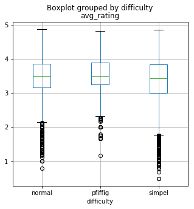

```python
# Show boxplots for recipe duration (time_mins) w.r.t. recipe difficulty
# (leicht = easy, mittel = medium, schwer = difficult)
chefdf.boxplot(column='avg_rating', by = 'difficulty', figsize=(5,5))
```

Boxplots are useful with categorical data that only has a few unique values, as then the distributions can be compared very well. However, we can see that the distributions are not too different: their averages lie very close to each other as well as the upper and lower quartiles. Still, the simple recipes have relatively and absolutely more recipes with a lower rating, which the lower whisker being at approx. 1.8, whereas the difficult ("pfiffig") recipes are rated higher more consistently.

Similar as above, we can create one DataFrame only for the numeric data in the recipes:

```python
# Show only numerical features per recipe in a new data frame
numerics = pd.DataFrame()
numerics['avg_rating'] = pd.to_numeric(clickdf['avg_rating'])
numerics['days'] = pd.to_numeric(clickdf['days'])
numerics['number_ratings'] = pd.to_numeric(clickdf['number_ratings'])
numerics['printed'] = pd.to_numeric(clickdf['printed'])
numerics['saved'] = pd.to_numeric(clickdf['saved'])
numerics['shared'] = pd.to_numeric(clickdf['shared'])
numerics.head(10)
```

|  | avg_rating | days | number_ratings | printed | saved | shared |
| --- | --- | --- | --- | --- | --- | --- |
| 3169 | 4.53 | 5715 | 164 | 607961 | 10407 | 1531 |
| 384 | 4.68 | 4802 | 2241 | 564662 | 38837 | 5079 |
| 1083 | 4.62 | 3967 | 2661 | 538629 | 54739 | 4253 |
| 531 | 4.67 | 5290 | 1066 | 454540 | 26569 | 5973 |
| 790 | 4.65 | 5581 | 2011 | 440263 | 42120 | 4259 |
| 619 | 4.66 | 3659 | 1670 | 415202 | 38376 | 1777 |
| 3328 | 4.52 | 3439 | 1069 | 396069 | 30618 | 1467 |
| 1415 | 4.60 | 3388 | 1633 | 394646 | 33136 | 1465 |
| 193 | 4.72 | 3891 | 760 | 360780 | 25549 | 2118 |
| 527 | 4.67 | 3623 | 548 | 359186 | 21924 | 2525 |

```python
numerics.describe()
```

|  | avg_rating | days | number_ratings | printed | saved | shared |
| --- | --- | --- | --- | --- | --- | --- |
| count | 223542.000000 | 223542.00000 | 223542.000000 | 223542.000000 | 223542.000000 | 223542.000000 |
| mean | 3.489463 | 3018.33795 | 11.449106 | 2629.867103 | 353.526675 | 24.875236 |
| std | 0.520291 | 1432.65235 | 46.842159 | 9264.475366 | 1229.162753 | 96.655639 |
| min | 0.500000 | 0.00000 | 1.000000 | 0.000000 | 0.000000 | 0.000000 |
| 25% | 3.090000 | 1922.00000 | 1.000000 | 285.000000 | 26.000000 | 0.000000 |
| 50% | 3.460000 | 3177.50000 | 3.000000 | 658.000000 | 67.000000 | 4.000000 |
| 75% | 3.850000 | 4043.00000 | 7.000000 | 1808.000000 | 209.000000 | 16.000000 |
| max | 4.870000 | 6343.00000 | 3337.000000 | 607961.000000 | 54739.000000 | 7260.000000 |

We can quickly check for correlations using Pearson's r for linear dependencies and Spearman's rho for dependencies that can be modeled with a monotonic function.

```python
# Are there correlations between these numerics?
# Calculate Pearson's r using our function from above:
num_pear, num_pearp = calculate_pearson(numerics)
num_peardf = pd.DataFrame(num_pear, columns=numerics.columns, index=numerics.columns)
num_peardf
```

|  | avg_rating | days | number_ratings | printed | saved | shared |
| --- | --- | --- | --- | --- | --- | --- |
| avg_rating | 1.000000 | 0.087782 | 0.329979 | 0.341925 | 0.376601 | 0.303046 |
| days | 0.087782 | 1.000000 | 0.122193 | 0.165764 | 0.159575 | 0.234787 |
| number_ratings | 0.329979 | 0.122193 | 1.000000 | 0.854402 | 0.921532 | 0.788923 |
| printed | 0.341925 | 0.165764 | 0.854402 | 1.000000 | 0.870940 | 0.849598 |
| saved | 0.376601 | 0.159575 | 0.921532 | 0.870940 | 1.000000 | 0.832335 |
| shared | 0.303046 | 0.234787 | 0.788923 | 0.849598 | 0.832335 | 1.000000 |

```python
# Respective p-Values for significance
num_pearpdf = pd.DataFrame(num_pearp, columns=numerics.columns, index=numerics.columns)
num_pearpdf
```

|  | avg_rating | days | number_ratings | printed | saved | shared |
| --- | --- | --- | --- | --- | --- | --- |
| avg_rating | 0.0 | 0.0 | 0.0 | 0.0 | 0.0 | 0.0 |
| days | 0.0 | 0.0 | 0.0 | 0.0 | 0.0 | 0.0 |
| number_ratings | 0.0 | 0.0 | 0.0 | 0.0 | 0.0 | 0.0 |
| printed | 0.0 | 0.0 | 0.0 | 0.0 | 0.0 | 0.0 |
| saved | 0.0 | 0.0 | 0.0 | 0.0 | 0.0 | 0.0 |
| shared | 0.0 | 0.0 | 0.0 | 0.0 | 0.0 | 0.0 |

Pearson's r shows high pairwise correlation between number_ratings and the popularity metrics (printed, saved, shared), which is understandable. Furthermore, the popularity metrics themselves have relatively high pairwise correlations. It is quite curious that the p-values are all exactly zero, which means that there is a 100% chance that the calculated correlations are correct and might be due to the high number of recipes that are in the dataset.

For nonlinear dependencies, we can use Spearman's rho:

```python
# Are there correlations between these numerics?
from scipy.stats.stats import spearmanr
num_speardf = pd.DataFrame(spearmanr(numerics)[0], columns=numerics.columns, index=numerics.columns)
num_speardf
```

|  | avg_rating | days | number_ratings | printed | saved | shared |
| --- | --- | --- | --- | --- | --- | --- |
| avg_rating | 1.000000 | 0.095820 | 0.775120 | 0.594058 | 0.641292 | 0.416193 |
| days | 0.095820 | 1.000000 | 0.318422 | 0.483387 | 0.468596 | 0.747783 |
| number_ratings | 0.775120 | 0.318422 | 1.000000 | 0.763770 | 0.814297 | 0.626061 |
| printed | 0.594058 | 0.483387 | 0.763770 | 1.000000 | 0.912870 | 0.805297 |
| saved | 0.641292 | 0.468596 | 0.814297 | 0.912870 | 1.000000 | 0.788957 |
| shared | 0.416193 | 0.747783 | 0.626061 | 0.805297 | 0.788957 | 1.000000 |

```python
# Show the p-Values for Spearman's rho
num_speardf = pd.DataFrame(spearmanr(numerics)[1], columns=numerics.columns, index=numerics.columns)
num_speardf
```

|  | avg_rating | days | number_ratings | printed | saved | shared |
| --- | --- | --- | --- | --- | --- | --- |
| avg_rating | 0.0 | 0.0 | 0.0 | 0.0 | 0.0 | 0.0 |
| days | 0.0 | 0.0 | 0.0 | 0.0 | 0.0 | 0.0 |
| number_ratings | 0.0 | 0.0 | 0.0 | 0.0 | 0.0 | 0.0 |
| printed | 0.0 | 0.0 | 0.0 | 0.0 | 0.0 | 0.0 |
| saved | 0.0 | 0.0 | 0.0 | 0.0 | 0.0 | 0.0 |
| shared | 0.0 | 0.0 | 0.0 | 0.0 | 0.0 | 0.0 |

Spearman's rho shows lower pairwise correlations for the popularity metrics and number_ratings than Pearson's r, but instead reveals other dependencies that avg_rating and days have with the other attributes. As we have seen in the analysis above already, the attribute shared seems to be the most likely one to aggregate over time.

The rating of recipes seem to be most dependent on the number of ratings with a coefficient of 0.77 and the number of saves with a coefficient of 0.64. These coefficients are not high enough to prove a strong dependency, but they might suggest a tendency.

To verify these assumptions we can also take a look at the scatter matrix for this DataFrame:

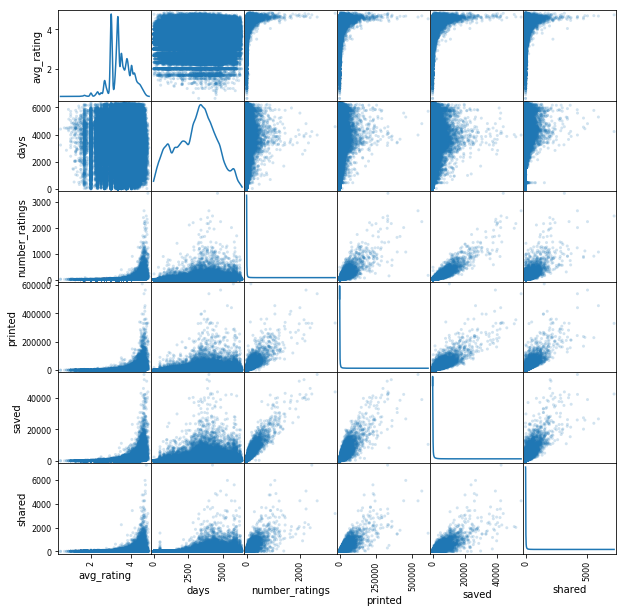

```python
from pandas.plotting import scatter_matrix
_ = scatter_matrix(numerics, alpha=0.2, figsize=(10, 10), diagonal='kde')
```

```python
# Function for adding 1 to an input:
def add_one(x):
    return x+1
```

```python
import numpy as np
log_numerics = pd.DataFrame()
log_numerics['avg_rating'] = pd.to_numeric(clickdf['avg_rating'])
log_numerics['days'] = pd.to_numeric(clickdf['days'])
log_numerics['number_ratings'] = pd.to_numeric(clickdf['number_ratings']).apply(np.log)
log_numerics['printed'] = pd.to_numeric(clickdf['printed']).apply(add_one).apply(np.log)
log_numerics['saved'] = pd.to_numeric(clickdf['saved']).apply(add_one).apply(np.log)
log_numerics['shared'] = pd.to_numeric(clickdf['shared']).apply(add_one).apply(np.log)

log_numerics.info()
```

```
<class 'pandas.core.frame.DataFrame'>
Int64Index: 223542 entries, 3169 to 146001
Data columns (total 6 columns):
avg_rating        223542 non-null float64
days              223542 non-null int64
number_ratings    223542 non-null float64
printed           223542 non-null float64
saved             223542 non-null float64
shared            223542 non-null float64
dtypes: float64(5), int64(1)
memory usage: 11.9 MB
```

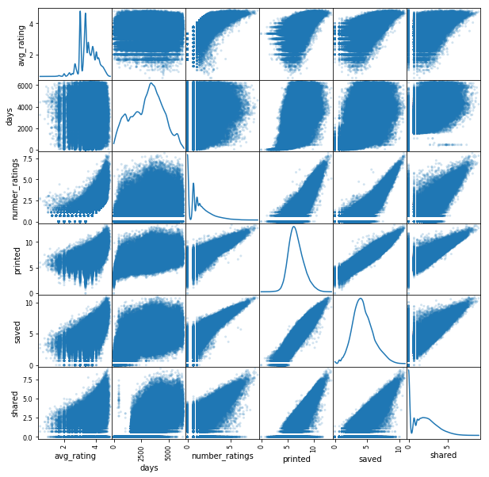

```python
_ = scatter_matrix(log_numerics, alpha=0.2, figsize=(10, 10), diagonal='kde')
```

```python
from scipy.stats.stats import spearmanr
num_speardf = pd.DataFrame(spearmanr(log_numerics)[0], columns=log_numerics.columns, index=log_numerics.columns)
num_speardf
```

|  | avg_rating | days | number_ratings | printed | saved | shared |
| --- | --- | --- | --- | --- | --- | --- |
| avg_rating | 1.000000 | 0.095820 | 0.775120 | 0.594058 | 0.641292 | 0.416193 |
| days | 0.095820 | 1.000000 | 0.318422 | 0.483387 | 0.468596 | 0.747783 |
| number_ratings | 0.775120 | 0.318422 | 1.000000 | 0.763770 | 0.814297 | 0.626061 |
| printed | 0.594058 | 0.483387 | 0.763770 | 1.000000 | 0.912870 | 0.805297 |
| saved | 0.641292 | 0.468596 | 0.814297 | 0.912870 | 1.000000 | 0.788957 |
| shared | 0.416193 | 0.747783 | 0.626061 | 0.805297 | 0.788957 | 1.000000 |

We can see that the distributions have shifted due to the log transformation and some correlations can be identified more easily in the scatter matrix. Spearman's rho has not changed for the transformed dataset, which shows that this correlation coefficient is robust to monotonous transformations. This representation of the transformed dataset confirms the assumptions about the dependencies that we have made further above.

### Title analysis

What can we learn from the recipe titles? We can either use the titles as they are (which does not provide very valuable results) or split the titles up into single words and perform further steps like word count or generating new features. For this, the data has to be cleaned further.

```python
# Show most common recipe names (Single-word titles)
chefdf['name'].value_counts().head(10)
```

```
Nudelsalat              112
Apfelkuchen              96
Gefüllte Champignons     81
Schokoladenkuchen        80
Nudelauflauf             78
Käsekuchen               76
Kürbissuppe              75
Eierlikörkuchen          75
Gefüllte Zucchini        71
Kartoffelsalat           69
Name: name, dtype: int64
```

While doing this, we also need to clean out characters/symbols and stopwords that do not help in identifying the recipe's content. This will be shown in the next steps:

```python
# Creates a list of single words from a list of multi-word names, removing most-common symbols
nameslist = []
for x in range(len(clickdf)):
    words = clickdf.iloc[x]['name']
    # filter unnecessary characters
    for char in ['"','-','=','!','(',')','.','♥',',',':','~','„','“','/','–','&','+',';','*','☆']:
        words = words.replace(char,'')
    words = words.split(' ',20)  # Split up titles with up to 20 whitespaces
    nameslist.extend(words)

# Remove empty elements, which occur when there is a space or symbol at the end of a name
nameslist = list(filter(None, nameslist))
nameslist[:10]
```

```
['Schnitzelpfanne',
 'Kürbissuppe',
 'mit',
 'Ingwer',
 'und',
 'Kokosmilch',
 'Lasagne',
 'Tiramisu',
 'Vanillekipferl',
 'KäseLauchSuppe']
```

```python
# list of german stop words from: https://www.ranks.nl/stopwords/german
# for removing words like "and", "or", etc.
text_file = open("data/stopwords.txt", "r", encoding = "ISO-8859-1")
stopwords  = text_file.readlines()
for i in range(len(stopwords)):
    stopwords[i] = stopwords[i].replace('\n','')
```

```python
# filter unnecessary stopwords from nameslist
for stop in stopwords:
    nameslist = list(filter(lambda k: stop != k, nameslist))

nameslist[:10]
```

```
['Schnitzelpfanne',
 'Kürbissuppe',
 'Ingwer',
 'Kokosmilch',
 'Lasagne',
 'Tiramisu',
 'Vanillekipferl',
 'KäseLauchSuppe',
 'Hackfleisch',
 'Chili']
```

```python
# Now, we can filter all list entries that contain numbers, so there are only words left.
# For that, we first need to define a function that can detect numbers in a string:
import re
def containsNumbers(string):
    return bool(re.search(r'\d', string))
```

```python
# Now we can filter nameslist with the new function:
nameslist = [w for w in nameslist if not containsNumbers(w)]
```

```python
# Now we can count the words in nameslist:
from collections import Counter
namecount = Counter(nameslist)
namecount.most_common(10)
```

```
[('la', 3839),
 ('Art', 3420),
 ('Tomaten', 3223),
 ('Salat', 3146),
 ('à', 2826),
 ('Torte', 2695),
 ('Gemüse', 2677),
 ('Kuchen', 2507),
 ('Sauce', 2480),
 ('Spaghetti', 2371)]
```

```python
# This still contains french and italian stop words (e.g. "á", "la", "alla"), as such words are often used in recipe titles.
# Additionally, there are still some German stopwords which have not been filtered before because they contain capital letters
# The following list has been extracted manually from the 1000 most frequent words
more_stopwords = ('Art', 'a', 'la', 'de', 'á', 'à', 'ohne', 'mal', 'lecker', 'Mein', 'dazu',
                  'ala', 'au', 'alla', 'ganz', 'schnelle', 'al', 'di', 'Die', 'Der', 'Das',
                  'MIT', 'Mit', 'a’la', 'Ein', 'so', 'u', 'e', 'E', 'nur', 'D', 'A', 'Co',
                  'I', 'um', 'ihn', 'and', 'Aus', 'II', 'Nr', 'Style', 'gut', 'ca', 'UND', 'con')

for stop in more_stopwords:
    nameslist = list(filter(lambda k: stop != k, nameslist))
```

```python
# 'Oma´s' 'Oma' 'Omas' 'Oma`s' "Oma's" are still in the list
for w in nameslist:
    if w == 'Oma´s' or w == 'Oma' or w == 'Oma`s' or w == 'Omas':
        w = "Oma's"
```

```python
# Count the words in nameslist, creates a dictionary with word counts
from collections import Counter
counts = Counter(nameslist)
counts.most_common(10)
```

```
[('Tomaten', 3223),
 ('Salat', 3146),
 ('Torte', 2695),
 ('Gemüse', 2677),
 ('Kuchen', 2507),
 ('Sauce', 2480),
 ('Spaghetti', 2371),
 ('Gefüllte', 2210),
 ('Muffins', 2151),
 ('Paprika', 2139)]
```

```python
# The counter can also be converted into a pandas DataFrame.
# (This provides a higher functionality than the limited Counter object.)
countsdf = pd.Series(dict(counts), name='count')
countsdf = countsdf.reset_index().sort_values(by='count', ascending=False)
countsdf.columns = ['word', 'count']
countsdf.index = countsdf['word']
countsdf = countsdf.drop('word', axis=1)

# Add log transformed counts:
import numpy as np
countsdf['log_count'] = countsdf['count'].apply(np.log)
countsdf.head(10)
```

| word | count | log_count |
| --- | --- | --- |
| Tomaten | 3223 | 8.078068 |
| Salat | 3146 | 8.053887 |
| Torte | 2695 | 7.899153 |
| Gemüse | 2677 | 7.892452 |
| Kuchen | 2507 | 7.826842 |
| Sauce | 2480 | 7.816014 |
| Spaghetti | 2371 | 7.771067 |
| Gefüllte | 2210 | 7.700748 |
| Muffins | 2151 | 7.673688 |
| Paprika | 2139 | 7.668094 |

```python
# Statistics for word counts
countsdf.describe()
```

|  | count | log_count |
| --- | --- | --- |
| count | 82065.000000 | 82065.000000 |
| mean | 6.200512 | 0.499592 |
| std | 50.341499 | 0.981213 |
| min | 1.000000 | 0.000000 |
| 25% | 1.000000 | 0.000000 |
| 50% | 1.000000 | 0.000000 |
| 75% | 2.000000 | 0.693147 |
| max | 3223.000000 | 8.078068 |

```
array([[<matplotlib.axes._subplots.AxesSubplot object at 0x7f9f2a632dd8>,
        <matplotlib.axes._subplots.AxesSubplot object at 0x7f9f294dc0b8>]], dtype=object)
```

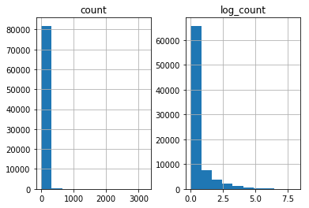

```python
countsdf.hist()
```

There is a total of 82,065 distinct words used in titles (after cleaning out stop words as shown above). Similar to the attributes viewed before, the words in recipe titles are exponentially distributed as well.

Additionally, we can see that even after performing a logarithmic transformation, the word counts still have a strong exponential distribution. Thus, the transformation does not help here.

```python
i = 0
for w in counts.most_common(100000):
    i += 1
    if w[1] == 99:
        print(w)
        print(i)
        break
```

```
('Elsässer', 99)
730
```

The first 729 words occur at least 100 times in the data set.

```python
countsdf[:729].describe()
```

|  | count | log_count |
| --- | --- | --- |
| count | 729.000000 | 729.000000 |
| mean | 346.213992 | 5.500576 |
| std | 402.335532 | 0.741063 |
| min | 100.000000 | 4.605170 |
| 25% | 135.000000 | 4.905275 |
| 50% | 203.000000 | 5.313206 |
| 75% | 381.000000 | 5.942799 |
| max | 3223.000000 | 8.078068 |

```python
# Export as CSV
countsdf = countsdf.drop('log_count', axis=1)  # log_count does not provide any benefit
countsdf.to_csv('exports/countsdf_chefkoch.csv')
```

#### Generating new features from recipe titles

##### How can we split up the titles in the DataFrame?

This can be done using the techniques shown above:

```python
# Creating a new data frame, because the features will be high-dimensional
namedf = pd.DataFrame()
#namedf['user'] = clickdf['user']
namedf['name'] = clickdf['name']
namedf.index = clickdf.index

# namelistdf = pd.DataFrame()
namedf.head(10)
```

|  | name |
| --- | --- |
| 3169 | Schnitzelpfanne |
| 384 | Kürbissuppe mit Ingwer und Kokosmilch |
| 1083 | Lasagne |
| 531 | Tiramisu |
| 790 | Vanillekipferl |
| 619 | Käse-Lauch-Suppe mit Hackfleisch |
| 3328 | Chili con Carne |
| 1415 | Pfannenkuchen / Pfannkuchen / Pfannekuchen / E... |
| 193 | Mascarpone - Himbeer - Quark |
| 527 | Italienischer Nudelsalat mit Rucola und getroc... |

```python
namelist = []
for w in namedf['name']:
    for char in ['"','-','=','!','(',')','.','♥',',',':','~','„','“','/','–','&','+',';','*','☆']:
        if char in w:
            w = w.replace(char,' ')
    namelist.append(w)
```

```python
tmplist = []

for title in namelist:

    title = title.split(' ')

    # Filter empty list entries
    title = list(filter(None, title))

    # Filter all stop words defined above
    for stop in stopwords:
        title = list(filter(lambda k: stop != k, title))
    for stop in more_stopwords:
        title = list(filter(lambda k: stop != k, title))

    # Remove numbers from titles
    title = [w for w in title if not containsNumbers(w)]

    tmplist.append(title)
```

```python
namedf['name'] = tmplist
# namedf.head(10)
```

```python
tmplist2 = []

for l in tmplist:
    for w in l:
        tmplist2.append(w)

from collections import Counter
count = Counter(tmplist2)
titlewords = count.most_common(100)
titlewords[:10]
```

```
[('Salat', 4343),
 ('Tomaten', 4296),
 ('Gemüse', 3524),
 ('Torte', 3443),
 ('Kuchen', 3362),
 ('Sauce', 3286),
 ('Apfel', 3145),
 ('Auflauf', 3076),
 ('Käse', 2856),
 ('Zucchini', 2848)]
```

```python
count['Kuchen']
```

```
3362
```

```python
# From each title, pick the two most common words to generate two new columns

toplist1 = []
toplist2 = []

for title in namedf['name']:
    try:
        topword1 = title[0]
        topword2 = title[1]
    except IndexError:
        try:
            topword1 = title[0]
            topword2 = title[0]
        except IndexError:
            pass
    for word in title:
        if count[word] > count[topword1]:
            topword2 = topword1
            topword1 = word
        if count[word] < count[topword1] & count[word] > count[topword2]:
            topword2 = word
    if topword1 == topword2:
        topword2 = None
    toplist1.append(topword1)
    toplist2.append(topword2)

namedf['top1'] = toplist1
namedf['top2'] = toplist2
# namedf.head(10)
```

```python
# print(count["Curry"], count["Hähnchen"])
# namedf.loc['Topfenparfait'.isin(namedf['name']), 'top1']
print(namedf['top1'].value_counts().head(10), namedf['top2'].value_counts().head(10))
```

```
Salat       4334
Tomaten     3985
Torte       3434
Gemüse      3367
Kuchen      3330
Sauce       2857
Auflauf     2687
Muffins     2529
Apfel       2428
Zucchini    2151
Name: top1, dtype: int64 Kartoffel    907
Schoko       781
Apfel        681
Sahne        626
Zucchini     594
Kokos        594
Käse         561
Gefüllte     561
Möhren       552
Spaghetti    532
Name: top2, dtype: int64
```

How many unique words are there in the top title words?

```python
print(namedf['top1'].describe()) #23.6k unique words in top1 column
print("-----")
print(namedf['top2'].describe()) #34.3k unique words in top2 column
```

```
count     223542
unique     23629
top        Salat
freq        4334
Name: top1, dtype: object
-----
count        184765
unique        34316
top       Kartoffel
freq            907
Name: top2, dtype: object
```

```python
toplist1.extend(toplist2)
# len(toplist1)
toplist1 = [w for w in toplist1 if w is not None]
top = Counter(toplist1)
len(top)  # 46.5k unique words in both columns combined
```

```
46470
```

By creating two new columns from the most frequent pair of words for each recipe, we have performed a very simple version of dimensionality reduction. In further analysis, we can now use these two words as a short identifier for the contents of each recipe.

We can now also add our pre-trained FastText vectors to namedf:

```python
import fasttext
word_model = fasttext.load_model('word_embeddings/prep_model.bin')

def lookup_vector(word):
    return word_model[word]
```

```python
lookup_vector('Brot')[:10]
```

```
[0.6021053194999695,
 -0.07773439586162567,
 -0.07206299155950546,
 -0.00033334168256260455,
 0.5664947628974915,
 0.22516869008541107,
 -0.012743216007947922,
 -0.07875770330429077,
 0.025176525115966797,
 -0.0024232864379882812]
```

```python
# Add the word vector for each top1 word to namedf:
namedf['vector'] = namedf['top1'].apply(lookup_vector)
namedf.head(10)
```

|  | name | top1 | top2 | vector |
| --- | --- | --- | --- | --- |
| 3169 | [Schnitzelpfanne] | Schnitzelpfanne | None | [0.17497532069683075, -0.5199864506721497, -0.... |
| 384 | [Kürbissuppe, Ingwer, Kokosmilch] | Ingwer | Kürbissuppe | [0.12412939965724945, 0.26520609855651855, -0.... |
| 1083 | [Lasagne] | Lasagne | None | [0.4355541467666626, -0.7065690159797668, 0.43... |
| 531 | [Tiramisu] | Tiramisu | None | [0.21500928699970245, -0.02308737300336361, -0... |
| 790 | [Vanillekipferl] | Vanillekipferl | None | [0.17782099545001984, -0.10057105869054794, -0... |
| 619 | [Käse, Lauch, Suppe, Hackfleisch] | Käse | Lauch | [0.5144494771957397, -0.15242810547351837, -0.... |
| 3328 | [Chili, Carne] | Chili | Carne | [-0.11874721199274063, 0.23951691389083862, -0... |
| 1415 | [Pfannenkuchen, Pfannkuchen, Pfannekuchen, Eie... | Pfannkuchen | Pfannenkuchen | [0.7198352217674255, -0.5997336506843567, 0.36... |
| 193 | [Mascarpone, Himbeer, Quark] | Quark | Himbeer | [0.39774826169013977, 0.05041850358247757, -0.... |
| 527 | [Italienischer, Nudelsalat, Rucola, getrocknet... | Tomaten | Nudelsalat | [0.05337012931704521, 0.28184106945991516, 0.3... |

```python
# Export for further analysis:
namedf.to_csv('exports/namedf_chefkoch.csv')
```

#### One-hot Encoding

For attributes that do not have too many distinct values, which repeat many times, one can use one-hot encoding. This technique creates a binary column for every distinct and fills a data point's entry with a one, if it contains the specified value.

For this purpose, we can create a function that encodes specific values from one column in a DataFrame into a new columns, of which each is named after that value.

```python
def encode_onehot(df, col, words):
    def contains_val(l):
        if val in l:
            return 1
        else: return 0

    for val in words:
        df[val] = df[col].apply(contains_val)
```

```python
# Example usage:
test = pd.DataFrame(['c', ['a', 'b'], ['c', 'a'], ['b', 'a', 'c']])
encode_onehot(test, 0, ['a', 'b', 'c'])
test
```

|  | 0 | a | b | c |
| --- | --- | --- | --- | --- |
| 0 | c | 0 | 0 | 1 |
| 1 | [a, b] | 1 | 1 | 0 |
| 2 | [c, a] | 1 | 0 | 1 |
| 3 | [b, a, c] | 1 | 1 | 1 |

We can use this function to encode the recipe ingredients in the next section. We only need to specify the DataFrame, the column that contains the values to be encoded and a list of selected values to encode, e.g. a list of most common words.